# AirBnB Sentiment Analysis - Dataset generation

```python
%reload_ext autoreload
%autoreload 2
%matplotlib inline
```

## Project Scope

- Use of sentiment analysis, of the reviews of each ad, to view the evaluation of the ad itself.
- Search for relationships between the price of a room and the day of the week, holidays, and time of year, and relationships between the price and the characteristics of a room to make a forecast.

Dataset: https://www.kaggle.com/brittabettendorf/berlin-airbnb-data

```python
import pandas as pd
import zipfile36 as zipfile
import langdetect
import os
import matplotlib.pyplot as plt
import gensim
import nltk
import seaborn as sns
```

```
d:\utenti\marco\desktop\insubria\laurea magistrale\data mining\airbnb-sentiment\venv\lib\site-packages\gensim\similarities\__init__.py:15: UserWarning: The gensim.similarities.levenshtein submodule is disabled, because the optional Levenshtein package <https://pypi.org/project/python-Levenshtein/> i…
  warnings.warn(msg)
```

## 1. Import of the reviews' dataset

The first step concerns the download of the datasets. In particular, for this purpose, the Kaggle APIs are used.

```python
!kaggle datasets download -d brittabettendorf/berlin-airbnb-data
```

```
berlin-airbnb-data.zip: Skipping, found more recently modified local copy (use --force to force download)
```

```python
zf = zipfile.ZipFile('berlin-airbnb-data.zip')
dfReviews = pd.read_csv(zf.open('reviews_summary.csv'))
dfReviews.head()
```

|  | listing_id | id | date | reviewer_id | reviewer_name | comments |
| --- | --- | --- | --- | --- | --- | --- |
| 0 | 2015 | 69544350 | 2016-04-11 | 7178145 | Rahel | Mein Freund und ich hatten gute gemütliche vie... |
| 1 | 2015 | 69990732 | 2016-04-15 | 41944715 | Hannah | Jan was very friendly and welcoming host! The ... |
| 2 | 2015 | 71605267 | 2016-04-26 | 30048708 | Victor | Un appartement tres bien situé dans un quartie... |
| 3 | 2015 | 73819566 | 2016-05-10 | 63697857 | Judy | It is really nice area, food, park, transport ... |
| 4 | 2015 | 74293504 | 2016-05-14 | 10414887 | Romina | Buena ubicación, el departamento no está orden... |

## 2. Data preprocessing

### 2.1 Null data-points removal

Once the dataset is available, it is needed to check whether there are some null data-points.

```python
dfReviews.info()
```

```
<class 'pandas.core.frame.DataFrame'>
RangeIndex: 401963 entries, 0 to 401962
Data columns (total 6 columns):
 #   Column         Non-Null Count   Dtype
---  ------         --------------   -----
 0   listing_id     401963 non-null  int64
 1   id             401963 non-null  int64
 2   date           401963 non-null  object
 3   reviewer_id    401963 non-null  int64
 4   reviewer_name  401963 non-null  object
 5   comments       401467 non-null  object
dtypes: int64(3), object(3)
memory usage: 18.4+ MB
```

```python
dfNullReviews = dfReviews[dfReviews['comments'].isnull()]
print(f'Number of null comments: {dfNullReviews.shape[0]}')
dfNullReviews.head()
```

```
Number of null comments: 496
```

|  | listing_id | id | date | reviewer_id | reviewer_name | comments |
| --- | --- | --- | --- | --- | --- | --- |
| 3049 | 42809 | 160781 | 2010-12-31 | 226667 | Frank | NaN |
| 4316 | 63468 | 75695155 | 2016-05-22 | 26052219 | Sebastian | NaN |
| 7984 | 139769 | 10110711 | 2014-01-31 | 10977586 | Mark | NaN |
| 8411 | 153015 | 234852734 | 2018-02-14 | 165971645 | Chiara | NaN |
| 10960 | 183918 | 11107030 | 2014-03-21 | 11014142 | Andrea | NaN |

```python
dfReviews.dropna(axis=0, how='any', inplace=True)
dfReviews.info()
```

```
<class 'pandas.core.frame.DataFrame'>
Int64Index: 401467 entries, 0 to 401962
Data columns (total 6 columns):
 #   Column         Non-Null Count   Dtype
---  ------         --------------   -----
 0   listing_id     401467 non-null  int64
 1   id             401467 non-null  int64
 2   date           401467 non-null  object
 3   reviewer_id    401467 non-null  int64
 4   reviewer_name  401467 non-null  object
 5   comments       401467 non-null  object
dtypes: int64(3), object(3)
memory usage: 21.4+ MB
```

### 2.2 Lowercase conversion

After the null data-points removal operation, it is needed to convert all the comments into lowercase strings.

```python
dfReviews['comments'] = dfReviews.apply(lambda x: x['comments'].lower(), axis=1)
dfReviews.head()
```

|  | listing_id | id | date | reviewer_id | reviewer_name | comments |
| --- | --- | --- | --- | --- | --- | --- |
| 0 | 2015 | 69544350 | 2016-04-11 | 7178145 | Rahel | mein freund und ich hatten gute gemütliche vie... |
| 1 | 2015 | 69990732 | 2016-04-15 | 41944715 | Hannah | jan was very friendly and welcoming host! the ... |
| 2 | 2015 | 71605267 | 2016-04-26 | 30048708 | Victor | un appartement tres bien situé dans un quartie... |
| 3 | 2015 | 73819566 | 2016-05-10 | 63697857 | Judy | it is really nice area, food, park, transport ... |
| 4 | 2015 | 74293504 | 2016-05-14 | 10414887 | Romina | buena ubicación, el departamento no está orden... |

### 2.3 Reviews' language detection

Since the comments are written in many languages, it can be useful to detect the language of each comment. This operation allows the selection of the comments based on their language (and also an eventual translation of all the comments into a common language).

In order to detect the language of the comments, the langdetect library is used.

```python
def get_lang_from_comment(dataframe):
    list_langs = []
    for index, comment in dataframe['comments'].iteritems():
        if index % 5000 == 0:
            print(f'Processed {index} rows...')
        try:
            comment_lang = langdetect.detect(comment[:50])
            list_langs.append(comment_lang)
        except:
            list_langs.append("None")

    return list_langs
```

Once the language for each comment is detected, it is added as a new column to the already existing dataframe. Then the resulting dataframe is saved into a .csv file.

Since this operation is very time-consuming, it is checked whether the operation has already been executed, and the results have been saved into a .csv file.

```python
if os.path.exists('reviews_summary_langs.csv'):
    dfReviews = pd.read_csv('reviews_summary_langs.csv')
else:
    dfReviews['Lang'] = get_lang_from_comment(dfReviews)
    dfReviews.to_csv('reviews_summary_langs.csv', sep=",", index=False, header=True)

dfReviews.head()
```

|  | listing_id | id | date | reviewer_id | reviewer_name | comments | Lang |
| --- | --- | --- | --- | --- | --- | --- | --- |
| 0 | 2015 | 69544350 | 2016-04-11 | 7178145 | Rahel | mein freund und ich hatten gute gemütliche vie... | de |
| 1 | 2015 | 69990732 | 2016-04-15 | 41944715 | Hannah | jan was very friendly and welcoming host! the ... | en |
| 2 | 2015 | 71605267 | 2016-04-26 | 30048708 | Victor | un appartement tres bien situé dans un quartie... | fr |
| 3 | 2015 | 73819566 | 2016-05-10 | 63697857 | Judy | it is really nice area, food, park, transport ... | en |
| 4 | 2015 | 74293504 | 2016-05-14 | 10414887 | Romina | buena ubicación, el departamento no está orden... | es |

```python
dfReviews['Lang'].unique()
```

```
array(['de', 'en', 'fr', 'es', 'no', 'ro', 'ca', 'sv', 'pt', 'it', 'ko',
       'nl', 'af', 'ru', 'zh-cn', 'fi', 'da', 'hu', 'None', 'vi', 'ja',
       'pl', 'cy', 'id', 'cs', 'et', 'hr', 'el', 'tr', 'sl', 'so',
       'zh-tw', 'tl', 'sk', 'sq', 'sw', 'uk', 'lv', 'mk', 'he', 'lt',
       'bg', 'th', 'ar'], dtype=object)
```

The rows in which the 'Lang' column shows the value 'None' are the ones that in the previous step have thrown some problems. In particular, the possible problems are the inability of the used technique to detect their language or the too-narrow length of the review.

```python
dfNoneLangReviews = dfReviews[dfReviews['Lang'] == 'None']
print(f'Number of reviews with None language: {dfNoneLangReviews.shape[0]}')
print(f'Percentage of reviews with None language: '
      f'{round(dfNoneLangReviews.shape[0] * 100 / dfReviews.shape[0],2)}%')
```

```
Number of reviews with None language: 648
Percentage of reviews with None language: 0.16%
```

#### 2.3.1 English reviews selection

The reviews written in english language are the interesting ones for this analysis.

```python
dfEnglishReviews = dfReviews[dfReviews['Lang'] == 'en']
dfEnglishReviews.head()
```

|  | listing_id | id | date | reviewer_id | reviewer_name | comments | Lang |
| --- | --- | --- | --- | --- | --- | --- | --- |
| 1 | 2015 | 69990732 | 2016-04-15 | 41944715 | Hannah | jan was very friendly and welcoming host! the ... | en |
| 3 | 2015 | 73819566 | 2016-05-10 | 63697857 | Judy | it is really nice area, food, park, transport ... | en |
| 6 | 2015 | 76603178 | 2016-05-28 | 29323516 | Laurent | we had a very nice stay in berlin, thanks to j... | en |
| 7 | 2015 | 77296201 | 2016-05-31 | 9025122 | Rasmus | great location close to mauerpark, kastanienal... | en |
| 9 | 2015 | 82322683 | 2016-06-27 | 73902920 | Mag | apartment very well located, close to everythi... | en |

```python
dfEnglishReviews.info()
```

```
<class 'pandas.core.frame.DataFrame'>
Int64Index: 268508 entries, 1 to 401466
Data columns (total 7 columns):
 #   Column         Non-Null Count   Dtype
---  ------         --------------   -----
 0   listing_id     268508 non-null  int64
 1   id             268508 non-null  int64
 2   date           268508 non-null  object
 3   reviewer_id    268508 non-null  int64
 4   reviewer_name  268508 non-null  object
 5   comments       268508 non-null  object
 6   Lang           268508 non-null  object
dtypes: int64(3), object(4)
memory usage: 16.4+ MB
```

### 2.4 Duplicates removal

Another required step is the removal of the duplicated reviews.

```python
print('Number of English reviews: {}'.format(dfEnglishReviews.shape[0]))
print('Number of unique English reviews: {}'.format(len(dfEnglishReviews['comments'].unique())))
```

```
Number of English reviews: 268508
Number of unique English reviews: 258767
```

```python
dfEnglishReviews = dfEnglishReviews.drop_duplicates(subset='comments')
print(f'Number of reviews after the duplicated removal: {dfEnglishReviews.shape[0]}')
```

```
Number of reviews after the duplicated removal: 258767
```

### 2.5 Non-English words removal

```python
dfEnglishReviews['comments'].iloc[172]
```

```
"britta’s apartment is perfect! clean, bright, fully-appointed , cozy. there is very convenience area, many cafes and restaurant around but quiet. it is situated few minutes from train and tram station. it made us perfect stay in berlin. we didn't have chance to meet britta but she is very kindness …
```

```python
from re import sub

dfEnglishReviews['comments'] = dfEnglishReviews.apply(
    lambda x: sub(r"[^A-Za-z]", " ", x['comments']), axis=1)
dfEnglishReviews['comments'].iloc[172]
```

```
'britta s apartment is perfect  clean  bright  fully appointed   cozy  there is very convenience area  many cafes and restaurant around but quiet  it is situated few minutes from train and tram station  it made us perfect stay in berlin  we didn t have chance to meet britta but she is very kindness …
```

### 2.6 Tokenization

In order to prepare the data for the analysis model, it is needed to perform a tokenization operation. For this purpose, the 'gensim' library is used.

```python
tokenizedEnglishReviews = dfEnglishReviews.apply(
    lambda x: gensim.utils.simple_preprocess(str(x['comments'])), axis=1)
tokenizedEnglishReviews
```

```
1         [jan, was, very, friendly, and, welcoming, hos...
3         [it, is, really, nice, area, food, park, trans...
6         [we, had, very, nice, stay, in, berlin, thanks...
7         [great, location, close, to, mauerpark, kastan...
9         [apartment, very, well, located, close, to, ev...
                                ...
401442    [great, place, to, stay, and, bit, far, though...
401443    [the, place, is, great, very, spacey, and, cle...
401445    [this, appartment, is, super, comfortable, and...
401453          [nice, quite, close, to, the, center, walk]
401462    [the, host, canceled, this, reservation, days,...
Length: 258767, dtype: object
```

### 2.7 Normalization

Another important step concerns the normalization of the reviews. For this purpose, the 'nltk' library is used.

In particular, the 'wordnet' and 'average_perceptron_tagger' packages are downloaded from the 'nltk' resources. The first package provides a 'Lemmatizer' that, given a word, converts it into its base form. The second package provides a method that, given a word, returns a tag representing its grammatical type.

```python
nltk.download('wordnet')
nltk.download('averaged_perceptron_tagger')
```

```
True
```

```python
from nltk.stem.wordnet import WordNetLemmatizer
from nltk.tag import pos_tag

def lemmatize_reviews(tokenized_reviews):
    lemmatizer = WordNetLemmatizer()
    lemmatized_reviews = []
    for tokens_review in tokenized_reviews:
        lemmatized_review = []
        for word, tag in pos_tag(tokens_review):
            if tag.startswith('NN'):
                pos = 'n'
            elif tag.startswith('VB'):
                pos = 'v'
            else:
                pos = 'a'
            lemmatized_review.append(lemmatizer.lemmatize(word, pos))
        lemmatized_reviews.append(lemmatized_review)

    return lemmatized_reviews
```

```python
lemmatizedTokenizedEnglishReviews = lemmatize_reviews(tokenizedEnglishReviews)
lemmatizedTokenizedEnglishReviews[:5]
```

```
[['jan',
  'be',
  'very',
  'friendly',
  'and',
  'welcome',
  'host',
  'the',
  'apartment',
  'be',
  'great',
  'and',
  'the',
  'area',
  'be',
  'sooo',
  'amaze',
  'lot',
  'of',
  'nice',
  'cafe',
  'and',
  'shop',
  'enjoy',
  'my',
  'time',
  'there',
  'lot'],
 ['it',
  'be',
  'really',
  'nice',
  'area',
  'food',
  'park',
  'transport',
  'be',
  'perfect'],
 ['we',
  'have',
```

[output cut: 103 more lines]

```
  'the',
  'basic',
  'equipment',
  'for',
  'one',
  'week',
  'stay',
  'jan',
  'be',
  'super',
  'accessible',
  'nice',
  'and',
  'always',
  'available']]
```

## 3. Sentiment Analysis

The idea of the sentiment analysis is to determine whether the reviews, of Airbnb activity in Berlin, are positive or negative.

### 3.1 Bigrams generation

In order to take into account some small sequences of words the bigrams are introduced. The Gensim Phrases package is used to automatically detect bigrams from a list of sentences.

```python
from gensim.models.phrases import Phrases, Phraser

phrases = Phrases(lemmatizedTokenizedEnglishReviews, min_count=3, progress_per=50000)

bigram = Phraser(phrases)

bigramReviews = bigram[lemmatizedTokenizedEnglishReviews]

bigramReviews[0]
```

```
['jan',
 'be',
 'very',
 'friendly',
 'and',
 'welcome',
 'host',
 'the',
 'apartment',
 'be',
 'great',
 'and',
 'the',
 'area',
 'be',
 'sooo',
 'amaze',
 'lot',
 'of',
 'nice',
 'cafe',
 'and',
 'shop',
 'enjoy',
 'my',
 'time',
 'there',
 'lot']
```

```python
from collections import defaultdict

dictWordFreq = defaultdict(int)
for review in bigramReviews:
    for i in review:
        dictWordFreq[i] += 1

len(dictWordFreq)
```

```
61035
```

```python
sorted(dictWordFreq, key=dictWordFreq.get, reverse=True)[:10]
```

```
['be', 'and', 'the', 'to', 'in', 'very', 'we', 'of', 'great', 'it']
```

### 3.2 Word2Vec model

Word2Vec is a group of models that tries to represent each word in a large text as a vector in a space of N dimensions (which we will call features) making similar words also be close to each other. In this particular case the CBOW architecture is used. In this way, each word in the corpus is predicted by its given context.

```python
from gensim.models import Word2Vec
from time import time

if os.path.exists('word2vec.model'):
    w2vModel = Word2Vec.load('word2vec.model')
else:
    w2vModel = Word2Vec(min_count=20,
                        window=4,
                        vector_size=300,
                        sample=6e-5,
                        alpha=0.03,
                        min_alpha=0.0007,
                        negative=20,
                        workers=4)

    t = time()
    w2vModel.build_vocab(bigramReviews, progress_per=10000)
    print('Time to build vocab: {} mins'.format(round((time() - t) / 60, 2)))

    t = time()
    w2vModel.train(bigramReviews,
                   total_examples=w2vModel.corpus_count,
                   epochs=30,
                   report_delay=1)
    print('Time to train the model: {} mins'.format(round((time() - t) / 60, 2)))

    w2vModel.save("word2vec.model")
```

As an example, it is possible to show the most similar words to a given word. This step allows to have a first look at the goodness of the Word2Vec model.

```python
w2vModel.wv.most_similar(positive=["apartment"])
```

```
[('flat', 0.8009026646614075),
 ('studio', 0.518069326877594),
 ('spacious', 0.5130087733268738),
 ('appartment', 0.5026397705078125),
 ('modern', 0.4899463653564453),
 ('clean', 0.4715781509876251),
 ('bright', 0.4463174343109131),
 ('itself', 0.43371134996414185),
 ('beautifully_appoint', 0.43370521068573),
 ('apt', 0.4198237657546997)]
```

### 3.3 Clustering model

For the clustering, the K-means technique is used.

```python
from sklearn.cluster import KMeans
import numpy as np

kmeansModel2Clusters = KMeans(n_clusters=2, max_iter=1000, random_state=42, n_init=50)
kmeansModel2Clusters.fit(X=w2vModel.wv.vectors.astype('double'))
```

```
KMeans(max_iter=1000, n_clusters=2, n_init=50, random_state=42)
```

In order to check which cluster is relatively positive, and which negative, it is possible to show the words that are the nearest to each cluster. In particular, the cosine similarity to the coordinates of first cluster is used to determine the similarity between cluster and word.

```python
w2vModel.wv.similar_by_vector(kmeansModel2Clusters.cluster_centers_[1],
                              topn=10,
                              restrict_vocab=None)
```

```
[('host', 0.6693733930587769),
 ('cordula', 0.5795034170150757),
 ('dany', 0.5769600868225098),
 ('nour', 0.5704270005226135),
 ('helpful', 0.5654318332672119),
 ('norman', 0.565179169178009),
 ('welcoming', 0.5552622079849243),
 ('friendly', 0.5529186129570007),
 ('franck', 0.5504003167152405),
 ('frieda', 0.5451028347015381)]
```

The 10 closest words to cluster number 1 in terms of cosine distance are shown. Looking at these words, it is possible to state that the cluster 1 is the cluster concerning the positive words, and the cluster 0 is the cluster concerning the negative words.

```python
negativeClusterIndex = 0
```

The next step concerns the assignment to each word of the sentiment score, computed through its converted cluster value, negative (-1) or positive (1), and its closeness score, that simply represents the closeness of a word to its cluster center.

```python
dfWords2Clusters = pd.DataFrame(
    w2vModel.wv.key_to_index.keys())

dfWords2Clusters.columns = ['words']

dfWords2Clusters['vectors'] = \
    dfWords2Clusters['words'].apply(
        lambda x: w2vModel.wv[f'{x}'])

dfWords2Clusters['cluster'] = \
    dfWords2Clusters['vectors'].apply(
        lambda x: kmeansModel2Clusters.predict([np.array(x)]))

dfWords2Clusters['cluster'] = \
    dfWords2Clusters['cluster'].apply(
        lambda x: x[0])

dfWords2Clusters.head()
```

|  | words | vectors | cluster |
| --- | --- | --- | --- |
| 0 | be | [0.09045758, 0.07613618, 0.12171817, -0.439189... | 0 |
| 1 | and | [-0.15569599, -0.20120987, 0.14106072, -0.4791... | 1 |
| 2 | the | [0.25615907, -0.26640812, 0.87123454, -0.50165... | 0 |
| 3 | to | [0.18882069, -0.59700924, -0.07487969, 0.04525... | 0 |
| 4 | in | [-0.20123443, -0.25175768, -0.03475116, -0.870... | 0 |

```python
dfWords2Clusters['cluster_value'] = [
    -1 if i==negativeClusterIndex else 1
    for i in dfWords2Clusters['cluster']]

dfWords2Clusters['closeness_score'] = \
    dfWords2Clusters.apply(
        lambda x: 1/(kmeansModel2Clusters.transform([x.vectors]).min()),
        axis=1)

dfWords2Clusters['sentiment_coeff'] = \
    dfWords2Clusters['closeness_score'] * \
    dfWords2Clusters['cluster_value']

dfWords2Clusters[
    dfWords2Clusters['cluster_value'] == -1].head()
```

|  | words | vectors | cluster | cluster_value | closeness_score | sentiment_coeff |
| --- | --- | --- | --- | --- | --- | --- |
| 0 | be | [0.09045758, 0.07613618, 0.12171817, -0.439189... | 0 | -1 | 0.188084 | -0.188084 |
| 2 | the | [0.25615907, -0.26640812, 0.87123454, -0.50165... | 0 | -1 | 0.156822 | -0.156822 |
| 3 | to | [0.18882069, -0.59700924, -0.07487969, 0.04525... | 0 | -1 | 0.112688 | -0.112688 |
| 4 | in | [-0.20123443, -0.25175768, -0.03475116, -0.870... | 0 | -1 | 0.144052 | -0.144052 |
| 7 | of | [0.47129914, -0.24029101, 0.18664457, -0.86250... | 0 | -1 | 0.099256 | -0.099256 |

With the above steps, a full dataframe of words is created, where each word has its own weighted cluster value, closeness score and sentiment score.

### 3.4 TF-IDF

TF-IDF is used to show how important a word is to a review.

```python
dfCleanedReviews = pd.DataFrame(
    [' '.join(review) for review in lemmatizedTokenizedEnglishReviews],
    columns=['comments'])

dfCleanedReviews.head()
```

|  | comments |
| --- | --- |
| 0 | jan be very friendly and welcome host the apar... |
| 1 | it be really nice area food park transport be ... |
| 2 | we have very nice stay in berlin thanks to jan... |
| 3 | great location close to mauerpark kastanienall... |
| 4 | apartment very well locate close to everything... |

To calculate the tfidf score of each word, the sklearn library is used. This step is conducted to consider how unique every word is for every sentence, and increase positive/negative signal associated with words that are highly specific for given sentence in comparison to whole corpus.

```python
from sklearn.feature_extraction.text import TfidfVectorizer

tfidf = TfidfVectorizer(norm=None)
transformed = tfidf.fit_transform(
    dfCleanedReviews['comments'].tolist())
features = pd.Series(tfidf.get_feature_names())
```

Finally, a vector containing the tfidf score for each review is created by replacing each word with the corresponding tfidf score.

```python
def create_tfidf_dictionary(x, transformed_file, features_file):
    """
    create dictionary for each input sentence x, where each word has assigned its tfidf score

    inspired  by function from this wonderful article:
    https://medium.com/analytics-vidhya/automated-keyword-extraction-from-articles-using-nlp-bfd864f41b34

    x - row of dataframe, containing sentences, and their indexes,
    transformed_file - all sentences transformed with TfidfVectorizer
    features - names of all words in corpus used in TfidfVectorizer
    """
    vector_coo = transformed_file[x.name].tocoo()
    vector_coo.col = features_file.iloc[vector_coo.col].values
    dict_from_coo = dict(zip(vector_coo.col, vector_coo.data))
    return dict_from_coo

def replace_tfidf_words(x, transformed_file, features_file):
    """
    replacing each word with it's calculated tfidf dictionary with scores of each word
    x - row of dataframe, containing sentences, and their indexes,
    transformed_file - all sentences transformed with TfidfVectorizer
    features - names of all words in corpus used in TfidfVectorizer
    """
    dictionary = create_tfidf_dictionary(x, transformed_file, features_file)
    try:
        res = list(map(lambda y:dictionary[f'{y}'], x['comments'].split()))
    except KeyError:
        res = [0 for i in x['comments'].split()]
    return res
```

```python
tfidfScores = dfCleanedReviews.apply(
    lambda x: replace_tfidf_words(x, transformed, features), axis=1)

tfidfScores.head()
```

```
0    [6.45518200427728, 3.6108140688773807, 1.62336...
1    [2.034512963851828, 2.407209379251587, 2.64191...
2    [2.091150860411193, 4.119858950780223, 4.87009...
3    [1.8501655371557688, 2.159718877149754, 2.7123...
4    [3.927308953862587, 3.246732537406179, 2.84084...
dtype: object
```

### 3.5 Closeness score

As the TF-IDF score, each word in every sentence is replaced by its own closeness score.

```python
dictSentiment2Clusters = dict(zip(
    dfWords2Clusters['words'].values,
    dfWords2Clusters['sentiment_coeff'].values))
```

```python
def replace_sentiment_words(word, sentiment_dict):
    """
    replacing each word with its associated sentiment score from sentiment dict
    """
    try:
        out = sentiment_dict[word]
    except KeyError:
        out = 0
    return out
```

```python
closenessScores2Clusters = \
    dfCleanedReviews['comments'].apply(
        lambda x: list(map(
            lambda y: replace_sentiment_words(y, dictSentiment2Clusters),
            x.split())))

closenessScores2Clusters.head()
```

```
0    [0.07985111004577553, -0.18808361904308693, 0....
1    [-0.1478535472173197, -0.18808361904308693, 0....
2    [0.11543748268633972, -0.13276076032773343, 0....
3    [0.1381656620939012, -0.11938607074241883, -0....
4    [-0.13562855624442288, 0.13688366219516676, -0...
Name: comments, dtype: object
```

### 3.6 Sentiment score computation

A new dataframe is created by associating all the previously-obtained values with each review.

```python
dfSentiment2ClustersTfidfReviews = \
    pd.DataFrame([closenessScores2Clusters,
                  tfidfScores,
                  dfCleanedReviews['comments']]).T

dfSentiment2ClustersTfidfReviews.columns = \
    ['sentiment_coeff', 'tfidf_scores', 'review']

dfSentiment2ClustersTfidfReviews['sentiment_rate'] = \
    dfSentiment2ClustersTfidfReviews.apply(
        lambda x: np.array(x.loc['sentiment_coeff']) @ np.array(x.loc['tfidf_scores']),
        axis=1)

dfSentiment2ClustersTfidfReviews['prediction'] =\
    (dfSentiment2ClustersTfidfReviews['sentiment_rate'] > 0)\
        .astype('int8')

dfSentiment2ClustersTfidfReviews.head()
```

|  | sentiment_coeff | tfidf_scores | review | sentiment_rate | prediction |
| --- | --- | --- | --- | --- | --- |
| 0 | [0.07985111004577553, -0.18808361904308693, 0.... | [6.45518200427728, 3.6108140688773807, 1.62336... | jan be very friendly and welcome host the apar... | -0.036251 | 0 |
| 1 | [-0.1478535472173197, -0.18808361904308693, 0.... | [2.034512963851828, 2.407209379251587, 2.64191... | it be really nice area food park transport be ... | -1.837079 | 0 |
| 2 | [0.11543748268633972, -0.13276076032773343, 0.... | [2.091150860411193, 4.119858950780223, 4.87009... | we have very nice stay in berlin thanks to jan... | -7.055429 | 0 |
| 3 | [0.1381656620939012, -0.11938607074241883, -0.... | [1.8501655371557688, 2.159718877149754, 2.7123... | great location close to mauerpark kastanienall... | -2.506551 | 0 |
| 4 | [-0.13562855624442288, 0.13688366219516676, -0... | [3.927308953862587, 3.246732537406179, 2.84084... | apartment very well locate close to everything... | -9.388832 | 0 |

It is also possible to show as an example the top-5 negative reviews, according to our sentiment prediction.

```python
dfNegativeSentiment = dfSentiment2ClustersTfidfReviews[
    dfSentiment2ClustersTfidfReviews['prediction'] == 0].sort_values(
        by=['sentiment_rate'])

print('Top-5 negative reviews:')
dfNegativeSentiment['review'].head().tolist()
```

```
Top-5 negative reviews:
```

```
['accuracy pretty sure this place be low income housing the building be super sketchy the lobby area be disgust dark and full of graffiti tags the elevator be the same way the wall and floor of hallway lead into the apartment look like they ve never be clean the neighbor have their possession scatte…
 'late in june we stay at rebecca appartment which be locate in ostkreuz berlin first the area be very convenient since you re immediately close to railway station which take you to the famous alexanderplatz for instance in minute or you can reach the airport in less than minute it be friendly neigh…
 'terrible experience this be my first time use airbnb be book for group of people for night fri sun in february when make the initial booking request the airbnb rate be include the service fee clean fee and surcharge for additional guest however this be decline by the owner and instead be send pre …
 'stay at andreas apartment be wonderful experience the apartment have very hipster feel with antique item and furniture all around the place along with modern feel the place itself be rather old with squeak floor we do once receive complaint from the downstairs neighbor state that our footstep coul…
 'would give this place star review but since there be no half round up luke be an accommodate host but his place be less so have stay in many airbnb but this be my first experience in private room with the host so want to accurately reflect my experience luke be kind and offer tip and extend invite…
```

Finally, the dataset can be saved into a .csv file.

```python
# dfSentiment2ClustersTfidfReviews.to_csv(
#     'sentiment_dataset_2_clusters.csv',
#     sep=',', index=False, header=True)
```

### 3.7 TextBlob

In order to understand the goodness of the obtained results, they can be compared to the ones obtained by an already-existing external library. In particular the TextBlob library is used, which is built on the shoulders of NLTK.

```python
from textblob import TextBlob
```

For each review, the sentiment score is computed by using TextBlob.

```python
textblobSentiment = dfCleanedReviews['comments'].apply(
    lambda x: TextBlob(x).sentiment.polarity)

textblobSentiment.head()
```

```
0    0.617500
1    0.800000
2    0.561250
3    0.643750
4    0.226042
Name: comments, dtype: float64
```

The TextBlob sentiment score is associated with each review.

```python
dfSentiment2ClustersTfidfReviews['textblob_sentiment'] = \
    textblobSentiment

dfSentiment2ClustersTfidfReviews['textblob_prediction'] = \
    (dfSentiment2ClustersTfidfReviews['textblob_sentiment'] > 0)\
        .astype('int8')

dfSentiment2ClustersTfidfReviews.head()
```

|  | sentiment_coeff | tfidf_scores | review | sentiment_rate | prediction | textblob_sentiment | textblob_prediction |
| --- | --- | --- | --- | --- | --- | --- | --- |
| 0 | [0.07985111004577553, -0.18808361904308693, 0.... | [6.45518200427728, 3.6108140688773807, 1.62336... | jan be very friendly and welcome host the apar... | -0.036251 | 0 | 0.617500 | 1 |
| 1 | [-0.1478535472173197, -0.18808361904308693, 0.... | [2.034512963851828, 2.407209379251587, 2.64191... | it be really nice area food park transport be ... | -1.837079 | 0 | 0.800000 | 1 |
| 2 | [0.11543748268633972, -0.13276076032773343, 0.... | [2.091150860411193, 4.119858950780223, 4.87009... | we have very nice stay in berlin thanks to jan... | -7.055429 | 0 | 0.561250 | 1 |
| 3 | [0.1381656620939012, -0.11938607074241883, -0.... | [1.8501655371557688, 2.159718877149754, 2.7123... | great location close to mauerpark kastanienall... | -2.506551 | 0 | 0.643750 | 1 |
| 4 | [-0.13562855624442288, 0.13688366219516676, -0... | [3.927308953862587, 3.246732537406179, 2.84084... | apartment very well locate close to everything... | -9.388832 | 0 | 0.226042 | 1 |

### 3.8 Sentiment Analysis Evaluation

Finally, it is possible to compare the obtained results by using the accuracy metrics. In particular, the Textblob results are used as truth labels, and the manually-obtained results are used as predictions. Even in this case, the sklearn library is used.

```python
from sklearn.metrics import accuracy_score, confusion_matrix, precision_score, recall_score, f1_score

def compute_test_scores(predictions, labels):

    df_conf_matrix = pd.DataFrame(confusion_matrix(labels, predictions))

    print(df_conf_matrix)

    test_scores = accuracy_score(labels, predictions), \
                  precision_score(labels, predictions), \
                  recall_score(labels, predictions), \
                  f1_score(labels, predictions)

    return test_scores
```

```python
testScores2ClustersSentiment = compute_test_scores(
    dfSentiment2ClustersTfidfReviews['prediction'],
    dfSentiment2ClustersTfidfReviews['textblob_prediction'])

dfTestScores2ClustersSentiment = pd.DataFrame([testScores2ClustersSentiment])
dfTestScores2ClustersSentiment.columns = ['accuracy', 'precision', 'recall', 'f1']
dfTestScores2ClustersSentiment = dfTestScores2ClustersSentiment.T
dfTestScores2ClustersSentiment.columns = ['scores']

print('Scores for sentiment analysis with 2 clusters and no stopwords: ')
dfTestScores2ClustersSentiment
```

```
        0      1
0    2861   1062
1  166563  88281
Scores for sentiment analysis with 2 clusters and no stopwords:
```

|  | scores |
| --- | --- |
| accuracy | 0.352216 |
| precision | 0.988113 |
| recall | 0.346412 |
| f1 | 0.512983 |

The sentiment analysis with 2 clusters shows bad results. So, it is possible to use both the elbow and the silhouette methods in order to check whether the clustering of the words can be performed with better results.

### 3.9 Clustering evaluation

The Elbow Method is used to find the best value of the number of cluster.

```python
def kmeans_elbow_method(vectors):
    wcss = []
    for i in range(1, 11):
        kmeans = KMeans(n_clusters = i, init = 'k-means++', random_state = 42)
        kmeans.fit(X=vectors)

        # inertia_ is sum of squared distance of samples to its closest cluster centers.
        wcss.append(kmeans.inertia_)
        print("inertia_", kmeans.inertia_)

    plt.plot(range(1, 11), wcss)
    plt.title('Elbow Method')
    plt.xlabel('Number of clusters')
    plt.ylabel('WCSS')
    plt.show()
```

```
inertia_ 1197053.6588201409
inertia_ 1151659.558594202
inertia_ 1115347.3522519232
inertia_ 1096038.177538068
inertia_ 1082101.1616705076
inertia_ 1069213.9233989643
inertia_ 1058186.253886657
inertia_ 1049101.2196385877
inertia_ 1041654.2658165627
inertia_ 1034365.4848706824
```

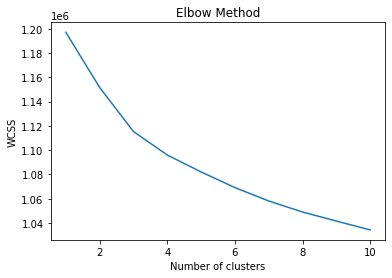

```python
kmeans_elbow_method(w2vModel.wv.vectors.astype('double'))
```

From the above Elbow method plot is not easy to establish a definitive value of number of clusters. So, in order to be more precise, the Silhouette method can be useful to understand the right number of cluster.

```python
from sklearn.metrics import silhouette_score

def kmeans_silhouette(x,range_clusters):
    for i, k in range_clusters :

        # Run the Kmeans algorithm
        km = KMeans(n_clusters = k, init = 'k-means++', random_state = 42)

        km.fit(x)
        labels = km.predict(x)

        print("For n_clusters =", k,
                  "The computed average silhouette_score is :",
              silhouette_score(x, labels, metric='euclidean'))
```

```python
rangeClusters = enumerate([2,3,4,5,6,7,8,9,10])
kmeans_silhouette(w2vModel.wv.vectors.astype('double'), rangeClusters)
```

```
For n_clusters = 2 The computed average silhouette_score is : 0.03430302979114765
For n_clusters = 3 The computed average silhouette_score is : 0.04693432189639514
For n_clusters = 4 The computed average silhouette_score is : 0.04095503514832024
For n_clusters = 5 The computed average silhouette_score is : -0.0005894831178587714
For n_clusters = 6 The computed average silhouette_score is : -0.009494873324793476
For n_clusters = 7 The computed average silhouette_score is : -0.015162937382469509
For n_clusters = 8 The computed average silhouette_score is : -0.01271461979777896
For n_clusters = 9 The computed average silhouette_score is : -0.05933921439711015
For n_clusters = 10 The computed average silhouette_score is : -0.057596102776052295
```

The obtained value show that the clustering with n_clusters = 3 could perform better results.

## 4. Sentiment analysis with 3 clusters

The performed steps are the same of the previous analysis. The steps concerning Word2Vec, TF-IDF and TextBlob are not applied because the results would be the same with respect to the previous ones.

### 4.1 Clustering model

```python
kmeansModel3Clusters = KMeans(n_clusters=3, max_iter=1000, random_state=42, n_init=50)
kmeansModel3Clusters.fit(X=w2vModel.wv.vectors.astype('double'))
```

```
KMeans(max_iter=1000, n_clusters=3, n_init=50, random_state=42)
```

```python
w2vModel.wv.similar_by_vector(
    kmeansModel3Clusters.cluster_centers_[0], topn=10, restrict_vocab=None)
```

```
[('that', 0.6367622017860413),
 ('no', 0.6151919364929199),
 ('metal', 0.6080124378204346),
 ('useless', 0.5866182446479797),
 ('broken', 0.5823581218719482),
 ('rug', 0.5738158226013184),
 ('plastic', 0.5711749196052551),
 ('tape', 0.5707537531852722),
 ('smelly', 0.5670434832572937),
 ('replacement', 0.5634723901748657)]
```

```python
w2vModel.wv.similar_by_vector(
    kmeansModel3Clusters.cluster_centers_[2], topn=10, restrict_vocab=None)
```

```
[('shop', 0.7630400061607361),
 ('bahn', 0.7551607489585876),
 ('restaurant', 0.7389747500419617),
 ('bar', 0.7280189394950867),
 ('cafe', 0.7133153080940247),
 ('supermarket', 0.7072442173957825),
 ('nearby', 0.7017354965209961),
 ('tram', 0.6940931677818298),
 ('station', 0.6876291036605835),
 ('metro', 0.6812832951545715)]
```

```python
negativeClusterIndex = 0
positiveClusterIndex = 2
```

```python
dfWords3Clusters = pd.DataFrame(
    w2vModel.wv.key_to_index.keys())

dfWords3Clusters.columns = ['words']

dfWords3Clusters['vectors'] = \
    dfWords3Clusters['words'].apply(
        lambda x: w2vModel.wv[f'{x}'])

dfWords3Clusters['cluster'] = \
    dfWords3Clusters['vectors'].apply(
        lambda x: kmeansModel3Clusters.predict([np.array(x)]))

dfWords3Clusters.cluster = \
    dfWords3Clusters['cluster'].apply(
        lambda x: x[0])

dfWords3Clusters.head()
```

|  | words | vectors | cluster |
| --- | --- | --- | --- |
| 0 | be | [0.09045758, 0.07613618, 0.12171817, -0.439189... | 0 |
| 1 | and | [-0.15569599, -0.20120987, 0.14106072, -0.4791... | 1 |
| 2 | the | [0.25615907, -0.26640812, 0.87123454, -0.50165... | 2 |
| 3 | to | [0.18882069, -0.59700924, -0.07487969, 0.04525... | 2 |
| 4 | in | [-0.20123443, -0.25175768, -0.03475116, -0.870... | 0 |

```python
dfWords3Clusters['cluster_value'] = \
    [-1 if i==negativeClusterIndex
     else 1 if i==positiveClusterIndex else 0
     for i in dfWords3Clusters['cluster']]

dfWords3Clusters['closeness_score'] = \
    dfWords3Clusters.apply(
        lambda x: 1/(kmeansModel3Clusters.transform([x.vectors]).min()),
        axis=1)

dfWords3Clusters['sentiment_coeff'] = \
    dfWords3Clusters['closeness_score'] * \
    dfWords3Clusters['cluster_value']

dfWords3Clusters[
    dfWords3Clusters['cluster_value'] == -1].head()
```

|  | words | vectors | cluster | cluster_value | closeness_score | sentiment_coeff |
| --- | --- | --- | --- | --- | --- | --- |
| 0 | be | [0.09045758, 0.07613618, 0.12171817, -0.439189... | 0 | -1 | 0.179801 | -0.179801 |
| 4 | in | [-0.20123443, -0.25175768, -0.03475116, -0.870... | 0 | -1 | 0.135022 | -0.135022 |
| 9 | it | [-0.3452291, -0.17170595, 0.35683635, 0.403672... | 0 | -1 | 0.140731 | -0.140731 |
| 12 | for | [0.25917652, -0.5541028, -0.70321125, -0.72414... | 0 | -1 | 0.108022 | -0.108022 |
| 14 | have | [0.70922995, -0.3451308, -0.5480699, -0.869590... | 0 | -1 | 0.144776 | -0.144776 |

### 4.2 Closeness score

```python
dictSentiment3Clusters = dict(zip(
    dfWords3Clusters['words'].values,
    dfWords3Clusters['sentiment_coeff'].values))
```

```python
closenessScores3Clusters = \
    dfCleanedReviews['comments'].apply(
        lambda x: list(map(
            lambda y: replace_sentiment_words(y, dictSentiment3Clusters),
            x.split())))

closenessScores3Clusters.head()
```

```
0    [0.0, -0.1798011283274767, 0.0, 0.0, 0.0, 0.0,...
1    [-0.14073132621331927, -0.1798011283274767, 0....
2    [0.0, -0.1447761464322067, 0.0, 0.0, 0.0, -0.1...
3    [0.0, 0.14353125369217165, 0.09988165591992858...
4    [0.0, 0.0, 0.0845358454151889, 0.1016659684988...
Name: comments, dtype: object
```

### 4.3 Sentiment score computation

```python
dfSentiment3ClustersTfidfReviews = pd.DataFrame(
    [closenessScores3Clusters,
     tfidfScores,
     dfCleanedReviews['comments']]).T

dfSentiment3ClustersTfidfReviews.columns = \
    ['sentiment_coeff', 'tfidf_scores', 'review']

dfSentiment3ClustersTfidfReviews['sentiment_rate'] = \
    dfSentiment3ClustersTfidfReviews.apply(
        lambda x: np.array(x.loc['sentiment_coeff']) @ np.array(x.loc['tfidf_scores']),
        axis=1)

dfSentiment3ClustersTfidfReviews['prediction'] = \
    (dfSentiment3ClustersTfidfReviews['sentiment_rate']>0)\
        .astype('int8')

dfSentiment3ClustersTfidfReviews.head()
```

|  | sentiment_coeff | tfidf_scores | review | sentiment_rate | prediction |
| --- | --- | --- | --- | --- | --- |
| 0 | [0.0, -0.1798011283274767, 0.0, 0.0, 0.0, 0.0,... | [6.45518200427728, 3.6108140688773807, 1.62336... | jan be very friendly and welcome host the apar... | 0.873900 | 1 |
| 1 | [-0.14073132621331927, -0.1798011283274767, 0.... | [2.034512963851828, 2.407209379251587, 2.64191... | it be really nice area food park transport be ... | 0.147324 | 1 |
| 2 | [0.0, -0.1447761464322067, 0.0, 0.0, 0.0, -0.1... | [2.091150860411193, 4.119858950780223, 4.87009... | we have very nice stay in berlin thanks to jan... | -0.364683 | 0 |
| 3 | [0.0, 0.14353125369217165, 0.09988165591992858... | [1.8501655371557688, 2.159718877149754, 2.7123... | great location close to mauerpark kastanienall... | 4.636182 | 1 |
| 4 | [0.0, 0.0, 0.0845358454151889, 0.1016659684988... | [3.927308953862587, 3.246732537406179, 2.84084... | apartment very well locate close to everything... | 3.231733 | 1 |

```python
# dfSentiment3ClustersTfidfReviews.to_csv(
#     'sentiment_dataset_3_clusters.csv',
#     sep=',', index=False, header=True)
```

```python
dfNegativeSentiment = dfSentiment3ClustersTfidfReviews[
    dfSentiment3ClustersTfidfReviews['prediction'] == 0].sort_values(
        by=['sentiment_rate'])

dfNegativeSentiment['review'].head().tolist()
```

```
['isolde be be wonderful host she live next door in close by hallway she show me around the apartment and make sure be take care of on my first day isolde be hilarious kindhearted and genuinely kind person we even share two meal and have coffee together this apartment be not typical european apartme…
 'frank work across the street from his apartment so arriving and check in be very easy frank be charm and be very thorough with explain how the apartment work this be frank own home and when he have guest he move next door into his partner home this mean frank be always on hand should you need some…
 'we originally book apartment but be move to when we arrive don think there be any real difference between the two be lovely the location be great minute walk to kochstrasse bahn and in the other direction hallesches tor bahnhof be about minute away the location be very short bahn ride away from un…
 'so this be juist my personal opinion about this listing it solid listing and completely functional clean all the basic for two people be fine new enlist the thing particularly didn like but alina have be great overall my main issue with this apartment be that it be lack lot of detail that value at…
 'it be clean well lay out in nice apartment on rd floor walk up the layout be spacious it be big building so it have these large room with high ceiling something be not use to live in in nyc so my frame of reference as baseline be much small apartment the floor be wide plank wood floor lacquer with…
```

### 4.4 TextBlob

```python
dfSentiment3ClustersTfidfReviews['textblob_sentiment'] = \
    textblobSentiment

dfSentiment3ClustersTfidfReviews['textblob_prediction'] = \
    (dfSentiment3ClustersTfidfReviews['textblob_sentiment'] > 0)\
        .astype('int8')

dfSentiment3ClustersTfidfReviews.head()
```

|  | sentiment_coeff | tfidf_scores | review | sentiment_rate | prediction | textblob_sentiment | textblob_prediction |
| --- | --- | --- | --- | --- | --- | --- | --- |
| 0 | [0.0, -0.1798011283274767, 0.0, 0.0, 0.0, 0.0,... | [6.45518200427728, 3.6108140688773807, 1.62336... | jan be very friendly and welcome host the apar... | 0.873900 | 1 | 0.617500 | 1 |
| 1 | [-0.14073132621331927, -0.1798011283274767, 0.... | [2.034512963851828, 2.407209379251587, 2.64191... | it be really nice area food park transport be ... | 0.147324 | 1 | 0.800000 | 1 |
| 2 | [0.0, -0.1447761464322067, 0.0, 0.0, 0.0, -0.1... | [2.091150860411193, 4.119858950780223, 4.87009... | we have very nice stay in berlin thanks to jan... | -0.364683 | 0 | 0.561250 | 1 |
| 3 | [0.0, 0.14353125369217165, 0.09988165591992858... | [1.8501655371557688, 2.159718877149754, 2.7123... | great location close to mauerpark kastanienall... | 4.636182 | 1 | 0.643750 | 1 |
| 4 | [0.0, 0.0, 0.0845358454151889, 0.1016659684988... | [3.927308953862587, 3.246732537406179, 2.84084... | apartment very well locate close to everything... | 3.231733 | 1 | 0.226042 | 1 |

### 4.5 Sentiment analysis evaluation

```python
testScores3ClustersSentiment = compute_test_scores(
    dfSentiment3ClustersTfidfReviews['prediction'],
    dfSentiment3ClustersTfidfReviews['textblob_prediction'])

dfTestScores3ClustersSentiment = pd.DataFrame([testScores3ClustersSentiment])
dfTestScores3ClustersSentiment.columns = ['accuracy', 'precision', 'recall', 'f1']
dfTestScores3ClustersSentiment = dfTestScores3ClustersSentiment.T
dfTestScores3ClustersSentiment.columns = ['scores']

print('Scores for sentiment analysis with 3 clusters and no stopwords: ')
dfTestScores3ClustersSentiment
```

```
        0      1
0    3189    734
1  172135  82709
Scores for sentiment analysis with 3 clusters and no stopwords:
```

|  | scores |
| --- | --- |
| accuracy | 0.331951 |
| precision | 0.991204 |
| recall | 0.324548 |
| f1 | 0.488987 |

## 5. Sentiment Analysis without stop words

The performed steps are the same as before.

### 5.1 Stop words removal

In order to obtain a list of the English common stop words, the 'stopwords' package of the 'nltk' library is used.

```python
nltk.download('stopwords')
```

```
True
```

```python
from nltk.corpus import stopwords

stopWords = stopwords.words('english')
stopWords[:10]
```

```
['i', 'me', 'my', 'myself', 'we', 'our', 'ours', 'ourselves', 'you', "you're"]
```

```python
def remove_stop_words(tokenized_reviews, stop_words):
    tokenized_reviews_without_stopwords = []
    for tokenized_review in tokenized_reviews:
        tokenized_reviews_without_stopwords.append(
            [word for word in tokenized_review if not word in stop_words]
        )
    return tokenized_reviews_without_stopwords
```

```python
lemmatizedTokenizedEnglishReviewsWithoutStopWords = remove_stop_words(
    lemmatizedTokenizedEnglishReviews, stopWords)
lemmatizedTokenizedEnglishReviewsWithoutStopWords[:5]
```

```
[['jan',
  'friendly',
  'welcome',
  'host',
  'apartment',
  'great',
  'area',
  'sooo',
  'amaze',
  'lot',
  'nice',
  'cafe',
  'shop',
  'enjoy',
  'time',
  'lot'],
 ['really', 'nice', 'area', 'food', 'park', 'transport', 'perfect'],
 ['nice',
  'stay',
  'berlin',
  'thanks',
  'jan',
  'premium',
  'situate',
  'apartment',
  'place',
  'big',
  'quiet',
  'functional',
  'also',
  'situate',
  'perfect',
  'neighbourhood',
  'jan',
  'welcome',
  'host',
  'eager',
  'help',
  'need',
  'provide',
```

[output cut: 32 more lines]

```
  'apartment',
  'locate',
  'inside',
  'building',
  'basic',
  'equipment',
  'one',
  'week',
  'stay',
  'jan',
  'super',
  'accessible',
  'nice',
  'always',
  'available']]
```

### 5.2 Bigrams generation

```python
phrasesWithoutStopWords = Phrases(lemmatizedTokenizedEnglishReviewsWithoutStopWords,
                                  min_count=3,
                                  progress_per=50000)

bigramWithoutStopWords = Phraser(phrasesWithoutStopWords)

bigramReviewsWithoutStopWords = bigramWithoutStopWords[
    lemmatizedTokenizedEnglishReviewsWithoutStopWords]

bigramReviewsWithoutStopWords[0]
```

```
['jan',
 'friendly',
 'welcome',
 'host',
 'apartment',
 'great',
 'area',
 'sooo',
 'amaze',
 'lot',
 'nice',
 'cafe',
 'shop',
 'enjoy',
 'time',
 'lot']
```

```python
dictWordFreq = defaultdict(int)
for review in bigramReviewsWithoutStopWords:
    for i in review:
        dictWordFreq[i] += 1

len(dictWordFreq)
```

```
64487
```

```python
sorted(dictWordFreq, key=dictWordFreq.get, reverse=True)[:10]
```

```
['great',
 'apartment',
 'stay',
 'place',
 'berlin',
 'nice',
 'location',
 'host',
 'clean',
 'good']
```

### 5.3 Word2Vec model

```python
if os.path.exists('word2vec_no_stopwords.model'):
    w2vModelWithoutStopWords = Word2Vec.load('word2vec_no_stopwords.model')
else:
    w2vModelWithoutStopWords = Word2Vec(min_count=20,
                                 window=4,
                                 vector_size=300,
                                 sample=6e-5,
                                 alpha=0.03,
                                 min_alpha=0.0007,
                                 negative=20,
                                 workers=4)

    t = time()
    w2vModelWithoutStopWords.build_vocab(bigramReviewsWithoutStopWords, progress_per=10000)
    print('Time to build vocab: {} mins'.format(round((time() - t) / 60, 2)))

    t = time()
    w2vModelWithoutStopWords.train(bigramReviewsWithoutStopWords,
                                   total_examples=w2vModelWithoutStopWords.corpus_count,
                                   epochs=30,
                                   report_delay=1)
    print('Time to train the model: {} mins'.format(round((time() - t) / 60, 2)))

    w2vModelWithoutStopWords.save("word2vec_no_stopwords.model")
```

```python
w2vModelWithoutStopWords.wv.most_similar(positive=["apartment"])
```

```
[('flat', 0.6878382563591003),
 ('spacious', 0.4964258074760437),
 ('modern', 0.48108017444610596),
 ('studio', 0.4650469124317169),
 ('clean', 0.4501889944076538),
 ('comfortably_furnish', 0.38306912779808044),
 ('building', 0.3798222839832306),
 ('bright', 0.377280056476593),
 ('modern_furnishing', 0.37452903389930725),
 ('beautifully_appoint', 0.37319716811180115)]
```

### 5.4 Clustering model

```python
kmeansModel2Clusters = KMeans(n_clusters=2, max_iter=1000, random_state=42, n_init=50)
kmeansModel2Clusters.fit(X=w2vModelWithoutStopWords.wv.vectors.astype('double'))
```

```
KMeans(max_iter=1000, n_clusters=2, n_init=50, random_state=42)
```

```python
w2vModelWithoutStopWords.wv.similar_by_vector(kmeansModel2Clusters.cluster_centers_[0],
                                              topn=10,
                                              restrict_vocab=None)
```

```
[('due_lack', 0.6634340882301331),
 ('wire', 0.660079300403595),
 ('useless', 0.636574387550354),
 ('unacceptable', 0.6353410482406616),
 ('rug', 0.6306374073028564),
 ('take_trash', 0.6300591826438904),
 ('filthy', 0.6290209293365479),
 ('leak', 0.6218292117118835),
 ('trap', 0.6210276484489441),
 ('smelly', 0.6185833811759949)]
```

```python
negativeClusterIndex = 0
```

```python
dfWords2ClustersWithoutStopWords = pd.DataFrame(
    w2vModelWithoutStopWords.wv.key_to_index.keys())

dfWords2ClustersWithoutStopWords.columns = ['words']

dfWords2ClustersWithoutStopWords['vectors'] = \
    dfWords2ClustersWithoutStopWords['words'].apply(
        lambda x: w2vModelWithoutStopWords.wv[f'{x}'])

dfWords2ClustersWithoutStopWords['cluster'] = \
    dfWords2ClustersWithoutStopWords['vectors'].apply(
        lambda x: kmeansModel2Clusters.predict([np.array(x)]))

dfWords2ClustersWithoutStopWords['cluster'] = \
    dfWords2ClustersWithoutStopWords['cluster'].apply(
        lambda x: x[0])

dfWords2ClustersWithoutStopWords.head()
```

|  | words | vectors | cluster |
| --- | --- | --- | --- |
| 0 | great | [0.021736015, -0.09696648, -0.20334733, 0.3184... | 1 |
| 1 | apartment | [0.09413033, -0.20562932, -0.09986646, -0.0815... | 1 |
| 2 | stay | [-0.04194155, 0.27263644, -0.30879694, -0.4886... | 1 |
| 3 | place | [0.1171688, -0.45740342, -0.18468466, 0.219762... | 1 |
| 4 | berlin | [-0.062057998, 0.043246496, -0.19278, -0.67646... | 1 |

```python
dfWords2ClustersWithoutStopWords['cluster_value'] = [
    -1 if i==negativeClusterIndex else 1
    for i in dfWords2ClustersWithoutStopWords['cluster']]

dfWords2ClustersWithoutStopWords['closeness_score'] = \
    dfWords2ClustersWithoutStopWords.apply(
        lambda x: 1/(kmeansModel2Clusters.transform([x.vectors]).min()),
        axis=1)

dfWords2ClustersWithoutStopWords['sentiment_coeff'] = \
    dfWords2ClustersWithoutStopWords['closeness_score'] * \
    dfWords2ClustersWithoutStopWords['cluster_value']

dfWords2ClustersWithoutStopWords[
    dfWords2ClustersWithoutStopWords['cluster_value'] == -1].head()
```

|  | words | vectors | cluster | cluster_value | closeness_score | sentiment_coeff |
| --- | --- | --- | --- | --- | --- | --- |
| 11 | room | [-0.1289804, -0.47577977, 0.45509025, 0.071285... | 0 | -1 | 0.135719 | -0.135719 |
| 18 | comfortable | [-0.105109595, -0.28582796, 0.23227535, -0.098... | 0 | -1 | 0.139571 | -0.139571 |
| 40 | like | [0.2838839, -0.5819455, 0.27681106, -0.0084737... | 0 | -1 | 0.132852 | -0.132852 |
| 45 | one | [-0.7768008, -0.64739054, 0.637206, -0.629718,... | 0 | -1 | 0.162380 | -0.162380 |
| 46 | bed | [-0.37433314, -0.19291034, 0.44292012, -0.3003... | 0 | -1 | 0.107758 | -0.107758 |

### 5.5 TF-IDF

```python
dfCleanedReviewsWithoutStopWords = pd.DataFrame(
    [' '.join(review) for review in lemmatizedTokenizedEnglishReviewsWithoutStopWords],
    columns=['comments'])

dfCleanedReviewsWithoutStopWords.head()
```

|  | comments |
| --- | --- |
| 0 | jan friendly welcome host apartment great area... |
| 1 | really nice area food park transport perfect |
| 2 | nice stay berlin thanks jan premium situate ap... |
| 3 | great location close mauerpark kastanienallee ... |
| 4 | apartment well locate close everything superma... |

```python
tfidfWithoutStopWords = TfidfVectorizer(norm=None)
transformed = tfidfWithoutStopWords.fit_transform(
    dfCleanedReviewsWithoutStopWords['comments'].tolist())
features = pd.Series(tfidfWithoutStopWords.get_feature_names())
```

```python
tfidfScoresWithoutStopWords = dfCleanedReviewsWithoutStopWords.apply(
    lambda x: replace_tfidf_words(x, transformed, features), axis=1)

tfidfScoresWithoutStopWords.head()
```

```
0    [6.45518200427728, 3.112217967778944, 3.555659...
1    [2.6419108992866036, 2.1582410989662106, 3.154...
2    [2.1582410989662106, 1.8573260246038177, 2.148...
3    [1.8501655371557688, 2.159718877149754, 2.7123...
4    [3.927308953862587, 2.8408487877668502, 6.4401...
dtype: object
```

### 5.6 Closeness score

```python
dictSentiment2ClustersWithoutStopWords = dict(zip(
    dfWords2ClustersWithoutStopWords['words'].values,
    dfWords2ClustersWithoutStopWords['sentiment_coeff'].values))
```

```python
closenessScores2ClustersWithoutStopWords = \
    dfCleanedReviewsWithoutStopWords['comments'].apply(
        lambda x: list(map(
            lambda y: replace_sentiment_words(y, dictSentiment2ClustersWithoutStopWords),
            x.split())))

closenessScores2ClustersWithoutStopWords.head()
```

```
0    [0.08274272026931886, 0.14438650901133268, 0.1...
1    [0.21196840433660452, 0.17771365086007282, 0.1...
2    [0.17771365086007282, 0.17679454909616302, 0.1...
3    [0.20011867647250559, 0.16337263418936798, 0.1...
4    [0.18721176816409277, 0.1347721306573096, 0.11...
Name: comments, dtype: object
```

### 5.7 Sentiment score computation

```python
dfSentiment2ClustersTfidfReviewsWithoutStopWords = \
    pd.DataFrame([closenessScores2ClustersWithoutStopWords,
                  tfidfScoresWithoutStopWords,
                  dfCleanedReviewsWithoutStopWords['comments']]).T

dfSentiment2ClustersTfidfReviewsWithoutStopWords.columns = \
    ['sentiment_coeff', 'tfidf_scores', 'review']

dfSentiment2ClustersTfidfReviewsWithoutStopWords['sentiment_rate'] = \
    dfSentiment2ClustersTfidfReviewsWithoutStopWords.apply(
        lambda x: np.array(x.loc['sentiment_coeff']) @ np.array(x.loc['tfidf_scores']),
        axis=1)

dfSentiment2ClustersTfidfReviewsWithoutStopWords['prediction'] =\
    (dfSentiment2ClustersTfidfReviewsWithoutStopWords['sentiment_rate'] > 0)\
        .astype('int8')

dfSentiment2ClustersTfidfReviewsWithoutStopWords.head()
```

|  | sentiment_coeff | tfidf_scores | review | sentiment_rate | prediction |
| --- | --- | --- | --- | --- | --- |
| 0 | [0.08274272026931886, 0.14438650901133268, 0.1... | [6.45518200427728, 3.112217967778944, 3.555659... | jan friendly welcome host apartment great area... | 8.102213 | 1 |
| 1 | [0.21196840433660452, 0.17771365086007282, 0.1... | [2.6419108992866036, 2.1582410989662106, 3.154... | really nice area food park transport perfect | 2.926502 | 1 |
| 2 | [0.17771365086007282, 0.17679454909616302, 0.1... | [2.1582410989662106, 1.8573260246038177, 2.148... | nice stay berlin thanks jan premium situate ap... | 15.925815 | 1 |
| 3 | [0.20011867647250559, 0.16337263418936798, 0.1... | [1.8501655371557688, 2.159718877149754, 2.7123... | great location close mauerpark kastanienallee ... | 4.887016 | 1 |
| 4 | [0.18721176816409277, 0.1347721306573096, 0.11... | [3.927308953862587, 2.8408487877668502, 6.4401... | apartment well locate close everything superma... | 5.763220 | 1 |

```python
dfNegativeSentiment = dfSentiment2ClustersTfidfReviewsWithoutStopWords[
    dfSentiment2ClustersTfidfReviewsWithoutStopWords['prediction'] == 0].sort_values(
        by=['sentiment_rate'])

print('Top-5 negative reviews:')
dfNegativeSentiment['review'].head().tolist()
```

```
Top-5 negative reviews:
```

```
['big flat heart neuk lln min station nice flatmate amazing room day everything fine flat mate nice reccomend every website hide airbnb sure like thanks benjamin sonia luca website hide airbnb website hide airbnb website hide airbnb website hide airbnb website hide airbnb website hide airbnb website…
 'one word mouse get apartment find mice run living room bedroom hysteria contact host benjamin respond right away tell us sunday know could nothing could check problem really mice problem tell family small child berlin high season would go tell would contact airbnb change apartment look hotel back …
 'good apartment good location unfortunately leave key inside room leave pay euro week also pay euro extra open door bil live berlin neighbor take care apartment check ask return key face face leave tell day would leave must put key mailbox bil leave nobody mention us one key berlin one week forget …
 'find marcos unit less expect airbnb reason front door complex lock front door unit break makeshift repair make door jamb could look door jamb door close make party comfortable night bed spread inside unit like flop house living room real bedroom room recently split half new wall last bed end hall …
 'stay berlin fantastic city dynamic alot offer especially christopher street day stay rosina place ok price fair berlin guess though apartment bit far important sight also issue awkward exchange worth mention communication book place week advance message never respond message day arrival make sure …
```

```python
# dfSentiment2ClustersTfidfReviewsWithoutStopWords.to_csv(
#     'sentiment_dataset_2_clusters_no_stopwords.csv',
#     sep=',', index=False, header=True)
```

### 5.8 TextBlob

```python
textblobSentimentWithoutStopWords = dfCleanedReviewsWithoutStopWords['comments'].apply(
    lambda x: TextBlob(x).sentiment.polarity)

textblobSentimentWithoutStopWords.head()
```

```
0    0.595000
1    0.800000
2    0.487500
3    0.587500
4    0.229762
Name: comments, dtype: float64
```

```python
dfSentiment2ClustersTfidfReviewsWithoutStopWords['textblob_sentiment'] = \
    textblobSentimentWithoutStopWords

dfSentiment2ClustersTfidfReviewsWithoutStopWords['textblob_prediction'] = \
    (dfSentiment2ClustersTfidfReviewsWithoutStopWords['textblob_sentiment'] > 0)\
        .astype('int8')

dfSentiment2ClustersTfidfReviewsWithoutStopWords.head()
```

|  | sentiment_coeff | tfidf_scores | review | sentiment_rate | prediction | textblob_sentiment | textblob_prediction |
| --- | --- | --- | --- | --- | --- | --- | --- |
| 0 | [0.08274272026931886, 0.14438650901133268, 0.1... | [6.45518200427728, 3.112217967778944, 3.555659... | jan friendly welcome host apartment great area... | 8.102213 | 1 | 0.595000 | 1 |
| 1 | [0.21196840433660452, 0.17771365086007282, 0.1... | [2.6419108992866036, 2.1582410989662106, 3.154... | really nice area food park transport perfect | 2.926502 | 1 | 0.800000 | 1 |
| 2 | [0.17771365086007282, 0.17679454909616302, 0.1... | [2.1582410989662106, 1.8573260246038177, 2.148... | nice stay berlin thanks jan premium situate ap... | 15.925815 | 1 | 0.487500 | 1 |
| 3 | [0.20011867647250559, 0.16337263418936798, 0.1... | [1.8501655371557688, 2.159718877149754, 2.7123... | great location close mauerpark kastanienallee ... | 4.887016 | 1 | 0.587500 | 1 |
| 4 | [0.18721176816409277, 0.1347721306573096, 0.11... | [3.927308953862587, 2.8408487877668502, 6.4401... | apartment well locate close everything superma... | 5.763220 | 1 | 0.229762 | 1 |

### 5.9 Sentiment analysis evaluation

```python
testScores2ClustersWithoutStopWordsSentiment = compute_test_scores(
    dfSentiment2ClustersTfidfReviewsWithoutStopWords['prediction'],
    dfSentiment2ClustersTfidfReviewsWithoutStopWords['textblob_prediction'])

dfTestScores2ClustersWithoutStopWordsSentiment = pd.DataFrame(
    [testScores2ClustersWithoutStopWordsSentiment])

dfTestScores2ClustersWithoutStopWordsSentiment.columns = \
    ['accuracy', 'precision', 'recall', 'f1']

dfTestScores2ClustersWithoutStopWordsSentiment = \
    dfTestScores2ClustersWithoutStopWordsSentiment.T

dfTestScores2ClustersWithoutStopWordsSentiment.columns = ['scores']

print('Scores for sentiment analysis with 2 clusters and no stopwords: ')
dfTestScores2ClustersWithoutStopWordsSentiment
```

```
       0       1
0   1425    3100
1  13517  240725
Scores for sentiment analysis with 2 clusters and no stopwords:
```

|  | scores |
| --- | --- |
| accuracy | 0.935784 |
| precision | 0.987286 |
| recall | 0.946834 |
| f1 | 0.966637 |

The obtained results seem to be very good. Even in this case it is possible to check whether there exists a better value for the number of cluster.

### 5.10 Clustering evaluation

```
inertia_ 1019374.8914507161
inertia_ 979036.4512069453
inertia_ 945731.9965046742
inertia_ 928825.8544302889
inertia_ 916296.311814165
inertia_ 903468.412742547
inertia_ 893577.2260768567
inertia_ 886675.7141103031
inertia_ 879206.5099118422
inertia_ 872744.2123647004
```

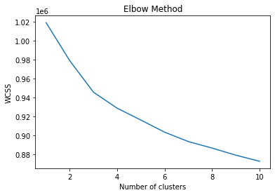

```python
kmeans_elbow_method(w2vModelWithoutStopWords.wv.vectors.astype('double'))
```

```python
rangeClusters = enumerate([2,3,4,5,6,7,8,9,10])
kmeans_silhouette(w2vModelWithoutStopWords.wv.vectors.astype('double'), rangeClusters)
```

```
For n_clusters = 2 The computed average silhouette_score is : 0.06882298045419695
For n_clusters = 3 The computed average silhouette_score is : 0.05184578923038232
For n_clusters = 4 The computed average silhouette_score is : 0.0489808665742103
For n_clusters = 5 The computed average silhouette_score is : 0.004672535626036191
For n_clusters = 6 The computed average silhouette_score is : -0.0008970731786193938
For n_clusters = 7 The computed average silhouette_score is : -0.007605956063358059
For n_clusters = 8 The computed average silhouette_score is : -0.04694576278840496
For n_clusters = 9 The computed average silhouette_score is : -0.04297953670725326
For n_clusters = 10 The computed average silhouette_score is : -0.04051978810825676
```

Even if the Silhouette method shows a worse score with n_clusters = 3, it can be interesting to check how much the model accuracy changes.

## 6. Sentiment analysis without stop words with 3 clusters

The performed steps are the same as before.

### 6.1 Clustering model

```python
kmeansModel3Clusters = KMeans(n_clusters=3, max_iter=1000, random_state=42, n_init=50)
kmeansModel3Clusters.fit(X=w2vModelWithoutStopWords.wv.vectors.astype('double'))
```

```
KMeans(max_iter=1000, n_clusters=3, n_init=50, random_state=42)
```

```python
w2vModelWithoutStopWords.wv.similar_by_vector(
    kmeansModel3Clusters.cluster_centers_[2], topn=10, restrict_vocab=None)
```

```
[('wire', 0.6604833006858826),
 ('due_lack', 0.6506068110466003),
 ('rug', 0.6456260085105896),
 ('useless', 0.6366190314292908),
 ('filthy', 0.6263508796691895),
 ('smelly', 0.6249639987945557),
 ('bathroom', 0.6226907968521118),
 ('leak', 0.6207293272018433),
 ('unacceptable', 0.6182073950767517),
 ('tape', 0.6162527203559875)]
```

```python
w2vModelWithoutStopWords.wv.similar_by_vector(
    kmeansModel3Clusters.cluster_centers_[0], topn=10, restrict_vocab=None)
```

```
[('shop', 0.7916755676269531),
 ('restaurant', 0.7737805843353271),
 ('nearby', 0.7589036822319031),
 ('cafe', 0.7558243870735168),
 ('bahn', 0.752166211605072),
 ('bar', 0.7403222918510437),
 ('minute_walk', 0.729056715965271),
 ('close', 0.718837320804596),
 ('supermarket', 0.7160413265228271),
 ('walk_distance', 0.7062254548072815)]
```

```python
negativeClusterIndex = 2
positiveClusterIndex = 0
```

```python
dfWords3ClustersWithoutStopWords = pd.DataFrame(
    w2vModelWithoutStopWords.wv.key_to_index.keys())

dfWords3ClustersWithoutStopWords.columns = ['words']

dfWords3ClustersWithoutStopWords['vectors'] = \
    dfWords3ClustersWithoutStopWords['words'].apply(
        lambda x: w2vModelWithoutStopWords.wv[f'{x}'])

dfWords3ClustersWithoutStopWords['cluster'] = \
    dfWords3ClustersWithoutStopWords['vectors'].apply(
        lambda x: kmeansModel3Clusters.predict([np.array(x)]))

dfWords3ClustersWithoutStopWords.cluster = \
    dfWords3ClustersWithoutStopWords['cluster'].apply(
        lambda x: x[0])

dfWords3ClustersWithoutStopWords.head()
```

|  | words | vectors | cluster |
| --- | --- | --- | --- |
| 0 | great | [0.021736015, -0.09696648, -0.20334733, 0.3184... | 1 |
| 1 | apartment | [0.09413033, -0.20562932, -0.09986646, -0.0815... | 1 |
| 2 | stay | [-0.04194155, 0.27263644, -0.30879694, -0.4886... | 1 |
| 3 | place | [0.1171688, -0.45740342, -0.18468466, 0.219762... | 1 |
| 4 | berlin | [-0.062057998, 0.043246496, -0.19278, -0.67646... | 0 |

```python
dfWords3ClustersWithoutStopWords['cluster_value'] = \
    [-1 if i==negativeClusterIndex
     else 1 if i==positiveClusterIndex else 0
     for i in dfWords3ClustersWithoutStopWords['cluster']]

dfWords3ClustersWithoutStopWords['closeness_score'] = \
    dfWords3ClustersWithoutStopWords.apply(
        lambda x: 1/(kmeansModel3Clusters.transform([x.vectors]).min()),
        axis=1)

dfWords3ClustersWithoutStopWords['sentiment_coeff'] = \
    dfWords3ClustersWithoutStopWords['closeness_score'] * \
    dfWords3ClustersWithoutStopWords['cluster_value']

dfWords3ClustersWithoutStopWords[
    dfWords3ClustersWithoutStopWords['cluster_value'] == -1].head()
```

|  | words | vectors | cluster | cluster_value | closeness_score | sentiment_coeff |
| --- | --- | --- | --- | --- | --- | --- |
| 11 | room | [-0.1289804, -0.47577977, 0.45509025, 0.071285... | 2 | -1 | 0.137974 | -0.137974 |
| 18 | comfortable | [-0.105109595, -0.28582796, 0.23227535, -0.098... | 2 | -1 | 0.142628 | -0.142628 |
| 40 | like | [0.2838839, -0.5819455, 0.27681106, -0.0084737... | 2 | -1 | 0.133966 | -0.133966 |
| 45 | one | [-0.7768008, -0.64739054, 0.637206, -0.629718,... | 2 | -1 | 0.161954 | -0.161954 |
| 46 | bed | [-0.37433314, -0.19291034, 0.44292012, -0.3003... | 2 | -1 | 0.109352 | -0.109352 |

### 6.2 Closeness score

```python
dictSentiment3ClustersWithoutStopWords = dict(zip(
    dfWords3ClustersWithoutStopWords['words'].values,
    dfWords3ClustersWithoutStopWords['sentiment_coeff'].values))
```

```python
closenessScores3ClustersWithoutStopWords = \
    dfCleanedReviewsWithoutStopWords['comments'].apply(
        lambda x: list(map(
            lambda y: replace_sentiment_words(y, dictSentiment3ClustersWithoutStopWords),
            x.split())))

closenessScores3ClustersWithoutStopWords.head()
```

```
0    [0.0, 0.0, 0.0, 0.0, 0.0, 0.0, 0.1530401787107...
1    [0.0, 0.0, 0.1530401787107593, 0.0962295034379...
2    [0.0, 0.0, 0.1417771922395551, 0.0, 0.0, -0.14...
3    [0.0, 0.19485141680948354, 0.14606870725559232...
4    [0.0, 0.12948971833364556, 0.14316824211234594...
Name: comments, dtype: object
```

### 6.3 Sentiment score computation

```python
dfSentiment3ClustersTfidfReviewsWithoutStopWords = pd.DataFrame(
    [closenessScores3ClustersWithoutStopWords,
     tfidfScoresWithoutStopWords,
     dfCleanedReviewsWithoutStopWords['comments']]).T

dfSentiment3ClustersTfidfReviewsWithoutStopWords.columns = \
    ['sentiment_coeff', 'tfidf_scores', 'review']

dfSentiment3ClustersTfidfReviewsWithoutStopWords['sentiment_rate'] = \
    dfSentiment3ClustersTfidfReviewsWithoutStopWords.apply(
        lambda x: np.array(x.loc['sentiment_coeff']) @ np.array(x.loc['tfidf_scores']),
        axis=1)

dfSentiment3ClustersTfidfReviewsWithoutStopWords['prediction'] = \
    (dfSentiment3ClustersTfidfReviewsWithoutStopWords['sentiment_rate']>0)\
        .astype('int8')

dfSentiment3ClustersTfidfReviewsWithoutStopWords.head()
```

|  | sentiment_coeff | tfidf_scores | review | sentiment_rate | prediction |
| --- | --- | --- | --- | --- | --- |
| 0 | [0.0, 0.0, 0.0, 0.0, 0.0, 0.0, 0.1530401787107... | [6.45518200427728, 3.112217967778944, 3.555659... | jan friendly welcome host apartment great area... | 3.171116 | 1 |
| 1 | [0.0, 0.0, 0.1530401787107593, 0.0962295034379... | [2.6419108992866036, 2.1582410989662106, 3.154... | really nice area food park transport perfect | 1.725799 | 1 |
| 2 | [0.0, 0.0, 0.1417771922395551, 0.0, 0.0, -0.14... | [2.1582410989662106, 1.8573260246038177, 2.148... | nice stay berlin thanks jan premium situate ap... | 4.913388 | 1 |
| 3 | [0.0, 0.19485141680948354, 0.14606870725559232... | [1.8501655371557688, 2.159718877149754, 2.7123... | great location close mauerpark kastanienallee ... | 3.140077 | 1 |
| 4 | [0.0, 0.12948971833364556, 0.14316824211234594... | [3.927308953862587, 2.8408487877668502, 6.4401... | apartment well locate close everything superma... | 2.336270 | 1 |

```python
# dfSentiment3ClustersTfidfReviewsWithoutStopWords.to_csv(
#     'sentiment_dataset_3_clusters_no_stopwords.csv',
#     sep=',', index=False, header=True)
```

```python
dfNegativeSentiment = dfSentiment3ClustersTfidfReviewsWithoutStopWords[
    dfSentiment3ClustersTfidfReviewsWithoutStopWords['prediction'] == 0].sort_values(
        by=['sentiment_rate'])

dfNegativeSentiment['review'].head().tolist()
```

```
['one word mouse get apartment find mice run living room bedroom hysteria contact host benjamin respond right away tell us sunday know could nothing could check problem really mice problem tell family small child berlin high season would go tell would contact airbnb change apartment look hotel back …
 'big flat heart neuk lln min station nice flatmate amazing room day everything fine flat mate nice reccomend every website hide airbnb sure like thanks benjamin sonia luca website hide airbnb website hide airbnb website hide airbnb website hide airbnb website hide airbnb website hide airbnb website…
 'good apartment good location unfortunately leave key inside room leave pay euro week also pay euro extra open door bil live berlin neighbor take care apartment check ask return key face face leave tell day would leave must put key mailbox bil leave nobody mention us one key berlin one week forget …
 'expect bait switch profile proudly state one apartment berlin air condition even fan let alone ac room describe king size bed perfect son sleep comfortably one person bed big twin nowhere near big enough two people sleep wanted leave soon got respond finally say give money back afford pay two plac…
 'find marcos unit less expect airbnb reason front door complex lock front door unit break makeshift repair make door jamb could look door jamb door close make party comfortable night bed spread inside unit like flop house living room real bedroom room recently split half new wall last bed end hall …
```

### 6.4 TextBlob

```python
dfSentiment3ClustersTfidfReviewsWithoutStopWords['textblob_sentiment'] = \
    textblobSentimentWithoutStopWords

dfSentiment3ClustersTfidfReviewsWithoutStopWords['textblob_prediction'] = \
    (dfSentiment3ClustersTfidfReviewsWithoutStopWords['textblob_sentiment'] > 0)\
        .astype('int8')

dfSentiment3ClustersTfidfReviewsWithoutStopWords.head()
```

|  | sentiment_coeff | tfidf_scores | review | sentiment_rate | prediction | textblob_sentiment | textblob_prediction |
| --- | --- | --- | --- | --- | --- | --- | --- |
| 0 | [0.0, 0.0, 0.0, 0.0, 0.0, 0.0, 0.1530401787107... | [6.45518200427728, 3.112217967778944, 3.555659... | jan friendly welcome host apartment great area... | 3.171116 | 1 | 0.595000 | 1 |
| 1 | [0.0, 0.0, 0.1530401787107593, 0.0962295034379... | [2.6419108992866036, 2.1582410989662106, 3.154... | really nice area food park transport perfect | 1.725799 | 1 | 0.800000 | 1 |
| 2 | [0.0, 0.0, 0.1417771922395551, 0.0, 0.0, -0.14... | [2.1582410989662106, 1.8573260246038177, 2.148... | nice stay berlin thanks jan premium situate ap... | 4.913388 | 1 | 0.487500 | 1 |
| 3 | [0.0, 0.19485141680948354, 0.14606870725559232... | [1.8501655371557688, 2.159718877149754, 2.7123... | great location close mauerpark kastanienallee ... | 3.140077 | 1 | 0.587500 | 1 |
| 4 | [0.0, 0.12948971833364556, 0.14316824211234594... | [3.927308953862587, 2.8408487877668502, 6.4401... | apartment well locate close everything superma... | 2.336270 | 1 | 0.229762 | 1 |

### 6.5 Sentiment analysis evaluation

```python
testScores3ClustersWithoutStopWordsSentiment = compute_test_scores(
    dfSentiment3ClustersTfidfReviewsWithoutStopWords['prediction'],
    dfSentiment3ClustersTfidfReviewsWithoutStopWords['textblob_prediction'])

dfTestScores3ClustersWithoutStopWordsSentiment = pd.DataFrame(
    [testScores3ClustersWithoutStopWordsSentiment])

dfTestScores3ClustersWithoutStopWordsSentiment.columns = \
    ['accuracy', 'precision', 'recall', 'f1']

dfTestScores3ClustersWithoutStopWordsSentiment = \
    dfTestScores3ClustersWithoutStopWordsSentiment.T

dfTestScores3ClustersWithoutStopWordsSentiment.columns = ['scores']

print('Scores for sentiment analysis with 3 clusters and no stopwords: ')
dfTestScores3ClustersWithoutStopWordsSentiment
```

```
        0       1
0    3263    1262
1  108395  145847
Scores for sentiment analysis with 3 clusters and no stopwords:
```

|  | scores |
| --- | --- |
| accuracy | 0.576233 |
| precision | 0.991421 |
| recall | 0.573654 |
| f1 | 0.726780 |

The obtained results are strongly worse with respect to the ones that could be expected. It was reasonable to expect a decrease in the accuracy score but not so marked.

```python
import calendar
from datetime import date
```

## 7. Relationships' investigation between price and calendar features

This analysis concerns the investigation of some relationships between the price of a room, or listing, and some time periods. In particular, the considered time periods are the days of the week, the seasons of the year and the holidays periods.

### 7.1 Import of the dataset

```python
zf = zipfile.ZipFile('berlin-airbnb-data.zip')
dfPricesDates = pd.read_csv(zf.open('calendar_summary.csv'))
dfPricesDates.head()
```

|  | listing_id | date | available | price |
| --- | --- | --- | --- | --- |
| 0 | 2015 | 2019-09-10 | f | NaN |
| 1 | 2015 | 2019-09-09 | f | NaN |
| 2 | 2015 | 2019-09-08 | f | NaN |
| 3 | 2015 | 2019-09-07 | f | NaN |
| 4 | 2015 | 2019-09-06 | f | NaN |

### 7.2 Columns exploration

Once the dataset is imported, it is needed to explore its columns to check whether some data preprocessing technique should be applied.

The first step concerns the removal of the null data-points.

```python
dfPricesDates.info()
```

```
<class 'pandas.core.frame.DataFrame'>
RangeIndex: 8231480 entries, 0 to 8231479
Data columns (total 4 columns):
 #   Column      Dtype
---  ------      -----
 0   listing_id  int64
 1   date        object
 2   available   object
 3   price       object
dtypes: int64(1), object(3)
memory usage: 251.2+ MB
```

```python
print('Number of null rows:', dfPricesDates['price'].isnull().sum())
```

```
Number of null rows: 6430639
```

```python
dfPricesDates.dropna(axis=0, how='any', inplace=True)
dfPricesDates.info()
```

```
<class 'pandas.core.frame.DataFrame'>
Int64Index: 1800841 entries, 128 to 8231474
Data columns (total 4 columns):
 #   Column      Dtype
---  ------      -----
 0   listing_id  int64
 1   date        object
 2   available   object
 3   price       object
dtypes: int64(1), object(3)
memory usage: 68.7+ MB
```

Since the 'available' column only contains a single value, it can be dropped.

```python
dfPricesDates['available'].unique()
```

```
array(['t'], dtype=object)
```

```python
dfPricesDates.drop(columns=['available'], inplace=True)
dfPricesDates.head()
```

|  | listing_id | date | price |
| --- | --- | --- | --- |
| 128 | 2015 | 2019-05-05 | $76.00 |
| 129 | 2015 | 2019-05-04 | $76.00 |
| 130 | 2015 | 2019-05-03 | $76.00 |
| 131 | 2015 | 2019-05-02 | $76.00 |
| 132 | 2015 | 2019-05-01 | $78.00 |

In order to deal with the 'price' column, its values need to be converted into numeric.

```python
type(dfPricesDates['price'].iloc[0])
```

```
str
```

```python
dfPricesDates['price'] = dfPricesDates['price'].apply(
    lambda x: x.replace(',', ''))

dfPricesDates['price'] = dfPricesDates['price'].apply(
    lambda x: float(x[1:]))

dfPricesDates.info()
```

```
<class 'pandas.core.frame.DataFrame'>
Int64Index: 1800841 entries, 128 to 8231474
Data columns (total 3 columns):
 #   Column      Dtype
---  ------      -----
 0   listing_id  int64
 1   date        object
 2   price       float64
dtypes: float64(1), int64(1), object(1)
memory usage: 55.0+ MB
```

Finally, also the type of the 'date' column is converted into datetime.

```python
dfPricesDates.info()
```

```
<class 'pandas.core.frame.DataFrame'>
Int64Index: 1800841 entries, 128 to 8231474
Data columns (total 3 columns):
 #   Column      Dtype
---  ------      -----
 0   listing_id  int64
 1   date        object
 2   price       float64
dtypes: float64(1), int64(1), object(1)
memory usage: 55.0+ MB
```

```python
dfPricesDates['date'] = pd.to_datetime(dfPricesDates['date'])
dfPricesDates.info()
```

```
<class 'pandas.core.frame.DataFrame'>
Int64Index: 1800841 entries, 128 to 8231474
Data columns (total 3 columns):
 #   Column      Dtype
---  ------      -----
 0   listing_id  int64
 1   date        datetime64[ns]
 2   price       float64
dtypes: datetime64[ns](1), float64(1), int64(1)
memory usage: 55.0 MB
```

```python
dfPricesDates.head()
```

|  | listing_id | date | price |
| --- | --- | --- | --- |
| 128 | 2015 | 2019-05-05 | 76.0 |
| 129 | 2015 | 2019-05-04 | 76.0 |
| 130 | 2015 | 2019-05-03 | 76.0 |
| 131 | 2015 | 2019-05-02 | 76.0 |
| 132 | 2015 | 2019-05-01 | 78.0 |

### 7.3 Price vs Day of the week

The first step concerns the creation of a new column for the day of the week. In particular, through the use of the calendar library, the week of the day is computed from the corresponding date.

```python
dfPricesDates['weekday'] = dfPricesDates.apply(
    lambda x: calendar.day_name[x['date'].weekday()], axis=1)

dfPricesDates.head()
```

|  | listing_id | date | price | weekday |
| --- | --- | --- | --- | --- |
| 128 | 2015 | 2019-05-05 | 76.0 | Sunday |
| 129 | 2015 | 2019-05-04 | 76.0 | Saturday |
| 130 | 2015 | 2019-05-03 | 76.0 | Friday |
| 131 | 2015 | 2019-05-02 | 76.0 | Thursday |
| 132 | 2015 | 2019-05-01 | 78.0 | Wednesday |

Then, it is possible to show, for each day of the week, the average price of all the listings.

```
<BarContainer object of 7 artists>
```

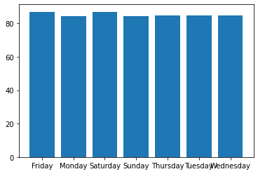

```python
weekdayMeans = dfPricesDates.groupby('weekday').price.mean()
plt.bar(weekdayMeans.index, weekdayMeans)
```

A new dataframe is created by computing, for each listing and for each day of the week, the average price.

```python
listingWeekdayMeans = dfPricesDates.groupby(['listing_id', 'weekday']).price.mean()
listingWeekdayMeans.head()
```

```
listing_id  weekday
2015        Friday      82.050000
            Monday      81.900000
            Saturday    82.100000
            Sunday      81.714286
            Thursday    81.750000
Name: price, dtype: float64
```

In order to work on the dataframe, the days of the week are converted into columns.

```python
dfListingWeekdayMeans = listingWeekdayMeans.unstack(level=1)
dfListingWeekdayMeans.head()
```

| weekday listing_id | Friday | Monday | Saturday | Sunday | Thursday | Tuesday | Wednesday |
| --- | --- | --- | --- | --- | --- | --- | --- |
| 2015 | 82.05 | 81.9 | 82.1 | 81.714286 | 81.75 | 81.9 | 81.9 |
| 3176 | 90.00 | 90.0 | 90.0 | 90.000000 | 90.00 | 90.0 | 90.0 |
| 3309 | 30.00 | 26.0 | 30.0 | 26.000000 | 26.00 | 26.0 | 26.0 |
| 7071 | 44.50 | 44.4 | 44.0 | 44.250000 | 44.50 | 44.4 | 44.5 |
| 9991 | 180.00 | 180.0 | 180.0 | 180.000000 | 180.00 | 180.0 | 180.0 |

Finally, the correlation between the days of the week is computed. In particular, the kendall's tau coefficient is used to measure the correlation degree.

```python
dfListingWeekdayMeans.corr(method='kendall')
```

| weekday | Friday | Monday | Saturday | Sunday | Thursday | Tuesday | Wednesday |
| --- | --- | --- | --- | --- | --- | --- | --- |
| Friday | 1.000000 | 0.940464 | 0.988121 | 0.946481 | 0.947083 | 0.940855 | 0.943441 |
| Monday | 0.940464 | 1.000000 | 0.941439 | 0.978557 | 0.972232 | 0.985404 | 0.977170 |
| Saturday | 0.988121 | 0.941439 | 1.000000 | 0.951268 | 0.942558 | 0.940675 | 0.941255 |
| Sunday | 0.946481 | 0.978557 | 0.951268 | 1.000000 | 0.973341 | 0.974599 | 0.972011 |
| Thursday | 0.947083 | 0.972232 | 0.942558 | 0.973341 | 1.000000 | 0.975663 | 0.983496 |
| Tuesday | 0.940855 | 0.985404 | 0.940675 | 0.974599 | 0.975663 | 1.000000 | 0.984663 |
| Wednesday | 0.943441 | 0.977170 | 0.941255 | 0.972011 | 0.983496 | 0.984663 | 1.000000 |

The correlation matrix shows that all the features are very highly correlated. So, it is possible to state that there are, meanly, very slight differences between the prices of the listings in the different days of the week.

### 7.4 Price vs Season

Even in this case, the first step concerns the creation of a new column for the season of the year.

```python
defaultYear = 2000
seasons = [('winter', (date(defaultYear,  1,  1),  date(defaultYear,  3, 20))),
           ('spring', (date(defaultYear,  3, 21),  date(defaultYear,  6, 20))),
           ('summer', (date(defaultYear,  6, 21),  date(defaultYear,  9, 22))),
           ('autumn', (date(defaultYear,  9, 23),  date(defaultYear, 12, 20))),
           ('winter', (date(defaultYear, 12, 21),  date(defaultYear, 12, 31)))]

def get_season(curr_date):
    curr_date = curr_date.replace(year=defaultYear)
    return next(season for season, (start, end) in seasons
                if start <= curr_date <= end)
```

```python
dfPricesDates['season'] = dfPricesDates['date'].apply(
    lambda x: get_season(x))

dfPricesDates.head()
```

|  | listing_id | date | price | weekday | season |
| --- | --- | --- | --- | --- | --- |
| 128 | 2015 | 2019-05-05 | 76.0 | Sunday | spring |
| 129 | 2015 | 2019-05-04 | 76.0 | Saturday | spring |
| 130 | 2015 | 2019-05-03 | 76.0 | Friday | spring |
| 131 | 2015 | 2019-05-02 | 76.0 | Thursday | spring |
| 132 | 2015 | 2019-05-01 | 78.0 | Wednesday | spring |

Then, it is possible to show, for each season of the year, the average price of all the listings.

```
<BarContainer object of 4 artists>
```

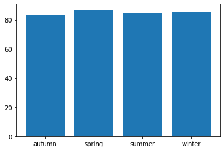

```python
seasonMeans = dfPricesDates.groupby('season').price.mean()
plt.bar(seasonMeans.index, seasonMeans)
```

A new dataframe is created by computing, for each listing and for each season of the year, the average price.

```python
listingSeasonMeans = dfPricesDates.groupby(['listing_id', 'season']).price.mean()
listingSeasonMeans.head()
```

```
listing_id  season
2015        autumn    76.000000
            spring    76.891304
            winter    84.788889
3176        autumn    90.000000
            spring    90.000000
Name: price, dtype: float64
```

In order to work on the dataframe, the seasons of the year are converted into columns.

```python
dfListingSeasonMeans = listingSeasonMeans.unstack(level=1)
dfListingSeasonMeans.head()
```

| season listing_id | autumn | spring | summer | winter |
| --- | --- | --- | --- | --- |
| 2015 | 76.000000 | 76.891304 | NaN | 84.788889 |
| 3176 | 90.000000 | 90.000000 | 90.000000 | NaN |
| 3309 | 27.066667 | 27.130435 | 27.191489 | 27.090909 |
| 7071 | 44.384615 | NaN | NaN | NaN |
| 9991 | 180.000000 | NaN | 180.000000 | 180.000000 |

Some listings show NaN values when the mean of the price for a season is considered. This may be caused by the unavailability of the listing during that considered period. So, these listings are not considered in the correlation analysis.

```python
dfListingSeasonMeans.info()
```

```
<class 'pandas.core.frame.DataFrame'>
Int64Index: 11764 entries, 2015 to 29867352
Data columns (total 4 columns):
 #   Column  Non-Null Count  Dtype
---  ------  --------------  -----
 0   autumn  10244 non-null  float64
 1   spring  6603 non-null   float64
 2   summer  5172 non-null   float64
 3   winter  9896 non-null   float64
dtypes: float64(4)
memory usage: 459.5 KB
```

```python
dfListingSeasonNonNullMeans = dfListingSeasonMeans.dropna(axis=0, how='any')
dfListingSeasonNonNullMeans.info()
```

```
<class 'pandas.core.frame.DataFrame'>
Int64Index: 4364 entries, 3309 to 29856708
Data columns (total 4 columns):
 #   Column  Non-Null Count  Dtype
---  ------  --------------  -----
 0   autumn  4364 non-null   float64
 1   spring  4364 non-null   float64
 2   summer  4364 non-null   float64
 3   winter  4364 non-null   float64
dtypes: float64(4)
memory usage: 170.5 KB
```

Finally, the correlation between the seasons of the year is computed.

```python
dfListingSeasonNonNullMeans.corr(method='kendall')
```

| season | autumn | spring | summer | winter |
| --- | --- | --- | --- | --- |
| autumn | 1.000000 | 0.947105 | 0.946358 | 0.907222 |
| spring | 0.947105 | 1.000000 | 0.964082 | 0.917361 |
| summer | 0.946358 | 0.964082 | 1.000000 | 0.892573 |
| winter | 0.907222 | 0.917361 | 0.892573 | 1.000000 |

Even in this case, the correlation matrix shows that all the features are very highly correlated. So, it is possible to state that there are, meanly, very slight differences between the prices of the listings in the different seasons.

### 7.5 Price vs Holiday

Even in this case, the first step concerns the creation of a new column for the holidays. In order to check whether a certain date is considered as holiday, the holidays library is used.

```python
import holidays

germanHolidays = holidays.Germany()
```

```python
dfPricesDates['holidays'] = dfPricesDates.apply(
    lambda x: int(x['date'] in germanHolidays or x['weekday'] == 'Sunday'), axis=1)

dfPricesDates.head()
```

|  | listing_id | date | price | weekday | season | holidays |
| --- | --- | --- | --- | --- | --- | --- |
| 128 | 2015 | 2019-05-05 | 76.0 | Sunday | spring | 1 |
| 129 | 2015 | 2019-05-04 | 76.0 | Saturday | spring | 0 |
| 130 | 2015 | 2019-05-03 | 76.0 | Friday | spring | 0 |
| 131 | 2015 | 2019-05-02 | 76.0 | Thursday | spring | 0 |
| 132 | 2015 | 2019-05-01 | 78.0 | Wednesday | spring | 1 |

Then, it is possible to show, for both the holidays and the non-holidays dates, the average price of all the listings.

```
<BarContainer object of 2 artists>
```

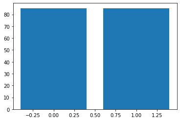

```python
holidaysMeans = dfPricesDates.groupby('holidays').price.mean()
plt.bar(holidaysMeans.index, holidaysMeans)
```

A new dataframe is created by computing, for each listing and for both holidays and non-holidays dayes, the average price.

```python
listingHolidaysMeans = dfPricesDates.groupby(['listing_id', 'holidays']).price.mean()
listingHolidaysMeans.head()
```

```
listing_id  holidays
2015        0           81.210526
            1           84.814815
3176        0           90.000000
            1           90.000000
3309        0           27.333333
Name: price, dtype: float64
```

In order to work on the dataframe, the holidays' values are converted into columns.

```python
dfListingHolidaysMeans = listingHolidaysMeans.unstack(level=1)
dfListingHolidaysMeans.head()
```

| holidays listing_id | 0 | 1 |
| --- | --- | --- |
| 2015 | 81.210526 | 84.814815 |
| 3176 | 90.000000 | 90.000000 |
| 3309 | 27.333333 | 26.083333 |
| 7071 | 44.409091 | 44.250000 |
| 9991 | 180.000000 | 180.000000 |

Some listings show NaN values when the mean of the price for a season is considered. This may be caused by the unavailability of the listing during that considered period. So, these listings are not initially considered in the correlation analysis.

```python
dfListingHolidaysMeans.info()
```

```
<class 'pandas.core.frame.DataFrame'>
Int64Index: 11764 entries, 2015 to 29867352
Data columns (total 2 columns):
 #   Column  Non-Null Count  Dtype
---  ------  --------------  -----
 0   0       11722 non-null  float64
 1   1       11376 non-null  float64
dtypes: float64(2)
memory usage: 275.7 KB
```

```python
dfListingHolidaysNonNullMeans = dfListingHolidaysMeans.dropna(axis=0, how='any')
dfListingHolidaysNonNullMeans.info()
```

```
<class 'pandas.core.frame.DataFrame'>
Int64Index: 11334 entries, 2015 to 29867352
Data columns (total 2 columns):
 #   Column  Non-Null Count  Dtype
---  ------  --------------  -----
 0   0       11334 non-null  float64
 1   1       11334 non-null  float64
dtypes: float64(2)
memory usage: 265.6 KB
```

Finally, the correlation between the holidays and non-holidays dates is computed.

```python
dfListingHolidaysNonNullMeans.corr(method='kendall')
```

| holidays | 0 | 1 |
| --- | --- | --- |
| 0 | 1.000000 | 0.961755 |
| 1 | 0.961755 | 1.000000 |

Even in this case, the correlation matrix shows that all the features are very highly correlated. So, it is possible to state that there are, meanly, very slight differences between the prices of the listings in the different days of the week.

## 8. Relationships' investigation between price and rooms' characteristics

This analysis concerns the investigation of some relationships between the price of a room, or listing, and its own characteristics. Then, the relationships should be used to create a model that is able to make predictions.

### 8.1 Import of the datasets

```python
dfListingsSummary = pd.read_csv(zf.open('listings_summary.csv'))
dfListingsSummary.head()
```

|  | id | listing_url | scrape_id | last_scraped | name | summary | space | description | experiences_offered | neighborhood_overview | ... | requires_license | license | jurisdiction_names | instant_bookable | is_business_travel_ready | cancellation_policy | require_guest_profile_picture | require_guest_phone_verification | calculated_host_listings_count | reviews_per_month |
| --- | --- | --- | --- | --- | --- | --- | --- | --- | --- | --- | --- | --- | --- | --- | --- | --- | --- | --- | --- | --- | --- |
| 0 | 2015 | https://www.airbnb.com/rooms/2015 | 20181107122246 | 2018-11-07 | Berlin-Mitte Value! Quiet courtyard/very central | Great location! 30 of 75 sq meters. This wood... | A+++ location! This „Einliegerwohnung“ is an e... | Great location! 30 of 75 sq meters. This wood... | none | It is located in the former East Berlin area o... | ... | t | NaN | NaN | f | f | strict_14_with_grace_period | f | f | 4 | 3.76 |
| 1 | 2695 | https://www.airbnb.com/rooms/2695 | 20181107122246 | 2018-11-07 | Prenzlauer Berg close to Mauerpark | NaN | In the summertime we are spending most of our ... | In the summertime we are spending most of our ... | none | NaN | ... | t | NaN | NaN | f | f | flexible | f | f | 1 | 1.42 |
| 2 | 3176 | https://www.airbnb.com/rooms/3176 | 20181107122246 | 2018-11-07 | Fabulous Flat in great Location | This beautiful first floor apartment is situa... | 1st floor (68m2) apartment on Kollwitzplatz/ P... | This beautiful first floor apartment is situa... | none | The neighbourhood is famous for its variety of... | ... | t | NaN | NaN | t | f | strict_14_with_grace_period | f | f | 1 | 1.25 |
| 3 | 3309 | https://www.airbnb.com/rooms/3309 | 20181107122246 | 2018-11-07 | BerlinSpot Schöneberg near KaDeWe | First of all: I prefer short-notice bookings. ... | Your room is really big and has 26 sqm, is ver... | First of all: I prefer short-notice bookings. ... | none | My flat is in the middle of West-Berlin, direc... | ... | t | NaN | NaN | f | f | strict_14_with_grace_period | f | f | 1 | 0.39 |
| 4 | 7071 | https://www.airbnb.com/rooms/7071 | 20181107122246 | 2018-11-07 | BrightRoom with sunny greenview! | Cozy and large room in the beautiful district ... | The BrightRoom is an approx. 20 sqm (215ft²), ... | Cozy and large room in the beautiful district ... | none | Great neighborhood with plenty of Cafés, Baker... | ... | t | NaN | NaN | f | f | moderate | f | f | 1 | 1.75 |

5 rows × 96 columns

### 8.2 Columns exploration

Once the dataset is imported, it is needed to explore its columns to check which of them describe a listing's characteristic.

```python
dfListingsSummary.columns
```

```
Index(['id', 'listing_url', 'scrape_id', 'last_scraped', 'name', 'summary',
       'space', 'description', 'experiences_offered', 'neighborhood_overview',
       'notes', 'transit', 'access', 'interaction', 'house_rules',
       'thumbnail_url', 'medium_url', 'picture_url', 'xl_picture_url',
       'host_id', 'host_url', 'host_name', 'host_since', 'host_location',
       'host_about', 'host_response_time', 'host_response_rate',
       'host_acceptance_rate', 'host_is_superhost', 'host_thumbnail_url',
       'host_picture_url', 'host_neighbourhood', 'host_listings_count',
       'host_total_listings_count', 'host_verifications',
       'host_has_profile_pic', 'host_identity_verified', 'street',
       'neighbourhood', 'neighbourhood_cleansed',
       'neighbourhood_group_cleansed', 'city', 'state', 'zipcode', 'market',
       'smart_location', 'country_code', 'country', 'latitude', 'longitude',
       'is_location_exact', 'property_type', 'room_type', 'accommodates',
       'bathrooms', 'bedrooms', 'beds', 'bed_type', 'amenities', 'square_feet',
       'price', 'weekly_price', 'monthly_price', 'security_deposit',
       'cleaning_fee', 'guests_included', 'extra_people', 'minimum_nights',
       'maximum_nights', 'calendar_updated', 'has_availability',
       'availability_30', 'availability_60', 'availability_90',
       'availability_365', 'calendar_last_scraped', 'number_of_reviews',
       'first_review', 'last_review', 'review_scores_rating',
       'review_scores_accuracy', 'review_scores_cleanliness',
       'review_scores_checkin', 'review_scores_communication',
       'review_scores_location', 'review_scores_value', 'requires_license',
       'license', 'jurisdiction_names', 'instant_bookable',
       'is_business_travel_ready', 'cancellation_policy',
       'require_guest_profile_picture', 'require_guest_phone_verification',
       'calculated_host_listings_count', 'reviews_per_month'],
      dtype='object')
```

Firstly, the columns concerning the room characteristics and the prices are selected.

```python
dfPricesListingTypes = dfListingsSummary[['id', 'room_type', 'accommodates',
                                          'bathrooms', 'bedrooms', 'beds', 'bed_type',
                                          'amenities', 'square_feet', 'price',
                                          'weekly_price', 'monthly_price',
                                          'security_deposit', 'cleaning_fee']]

dfPricesListingTypes.head()
```

|  | id | room_type | accommodates | bathrooms | bedrooms | beds | bed_type | amenities | square_feet | price | weekly_price | monthly_price | security_deposit | cleaning_fee |
| --- | --- | --- | --- | --- | --- | --- | --- | --- | --- | --- | --- | --- | --- | --- |
| 0 | 2015 | Entire home/apt | 3 | 1.0 | 1.0 | 2.0 | Real Bed | {TV,"Cable TV",Wifi,Kitchen,Gym,Heating,"Famil... | NaN | $60.00 | NaN | NaN | $200.00 | $30.00 |
| 1 | 2695 | Private room | 2 | 1.0 | 1.0 | 1.0 | Real Bed | {Wifi,Kitchen,Elevator,Heating,Washer,Essentia... | NaN | $17.00 | NaN | NaN | $0.00 | $0.00 |
| 2 | 3176 | Entire home/apt | 4 | 1.0 | 1.0 | 2.0 | Real Bed | {Internet,Wifi,Kitchen,"Buzzer/wireless interc... | 720.0 | $90.00 | $520.00 | $1,900.00 | $200.00 | $50.00 |
| 3 | 3309 | Private room | 2 | 1.0 | 1.0 | 1.0 | Pull-out Sofa | {Internet,Wifi,"Pets allowed","Pets live on th... | 0.0 | $26.00 | $175.00 | $599.00 | $250.00 | $30.00 |
| 4 | 7071 | Private room | 2 | 1.0 | 1.0 | 2.0 | Real Bed | {Wifi,Heating,"Family/kid friendly",Essentials... | NaN | $42.00 | NaN | NaN | $0.00 | $0.00 |

```python
dfPricesListingTypes.info()
```

```
<class 'pandas.core.frame.DataFrame'>
RangeIndex: 22552 entries, 0 to 22551
Data columns (total 14 columns):
 #   Column            Non-Null Count  Dtype
---  ------            --------------  -----
 0   id                22552 non-null  int64
 1   room_type         22552 non-null  object
 2   accommodates      22552 non-null  int64
 3   bathrooms         22520 non-null  float64
 4   bedrooms          22534 non-null  float64
 5   beds              22512 non-null  float64
 6   bed_type          22552 non-null  object
 7   amenities         22552 non-null  object
 8   square_feet       446 non-null    float64
 9   price             22552 non-null  object
 10  weekly_price      3681 non-null   object
 11  monthly_price     2659 non-null   object
 12  security_deposit  13191 non-null  object
 13  cleaning_fee      15406 non-null  object
dtypes: float64(4), int64(2), object(8)
memory usage: 2.4+ MB
```

Looking at the null data-points, the columns 'square_feet', 'weekly_price', 'monthly_price', 'security_deposit' and 'cleaning_fee' can be dropped.

```python
dfPricesListingTypes = dfPricesListingTypes.drop(
    columns=['square_feet', 'weekly_price', 'monthly_price', 'security_deposit',
             'cleaning_fee'])

dfPricesListingTypes.head()
```

|  | id | room_type | accommodates | bathrooms | bedrooms | beds | bed_type | amenities | price |
| --- | --- | --- | --- | --- | --- | --- | --- | --- | --- |
| 0 | 2015 | Entire home/apt | 3 | 1.0 | 1.0 | 2.0 | Real Bed | {TV,"Cable TV",Wifi,Kitchen,Gym,Heating,"Famil... | $60.00 |
| 1 | 2695 | Private room | 2 | 1.0 | 1.0 | 1.0 | Real Bed | {Wifi,Kitchen,Elevator,Heating,Washer,Essentia... | $17.00 |
| 2 | 3176 | Entire home/apt | 4 | 1.0 | 1.0 | 2.0 | Real Bed | {Internet,Wifi,Kitchen,"Buzzer/wireless interc... | $90.00 |
| 3 | 3309 | Private room | 2 | 1.0 | 1.0 | 1.0 | Pull-out Sofa | {Internet,Wifi,"Pets allowed","Pets live on th... | $26.00 |
| 4 | 7071 | Private room | 2 | 1.0 | 1.0 | 2.0 | Real Bed | {Wifi,Heating,"Family/kid friendly",Essentials... | $42.00 |

Since it is not needed in order to make predictions, the column 'id' is dropped.

```python
dfPricesListingTypes = dfPricesListingTypes.drop(columns=['id'])
dfPricesListingTypes.head()
```

|  | room_type | accommodates | bathrooms | bedrooms | beds | bed_type | amenities | price |
| --- | --- | --- | --- | --- | --- | --- | --- | --- |
| 0 | Entire home/apt | 3 | 1.0 | 1.0 | 2.0 | Real Bed | {TV,"Cable TV",Wifi,Kitchen,Gym,Heating,"Famil... | $60.00 |
| 1 | Private room | 2 | 1.0 | 1.0 | 1.0 | Real Bed | {Wifi,Kitchen,Elevator,Heating,Washer,Essentia... | $17.00 |
| 2 | Entire home/apt | 4 | 1.0 | 1.0 | 2.0 | Real Bed | {Internet,Wifi,Kitchen,"Buzzer/wireless interc... | $90.00 |
| 3 | Private room | 2 | 1.0 | 1.0 | 1.0 | Pull-out Sofa | {Internet,Wifi,"Pets allowed","Pets live on th... | $26.00 |
| 4 | Private room | 2 | 1.0 | 1.0 | 2.0 | Real Bed | {Wifi,Heating,"Family/kid friendly",Essentials... | $42.00 |

The column 'price' must be converted into numeric.

```python
dfPricesListingTypes['price'] = dfPricesListingTypes['price'].apply(
    lambda x: x.replace(',', ''))

dfPricesListingTypes['price'] = dfPricesListingTypes['price'].apply(
    lambda x: float(x[1:]))

dfPricesListingTypes.info()
```

```
<class 'pandas.core.frame.DataFrame'>
RangeIndex: 22552 entries, 0 to 22551
Data columns (total 8 columns):
 #   Column        Non-Null Count  Dtype
---  ------        --------------  -----
 0   room_type     22552 non-null  object
 1   accommodates  22552 non-null  int64
 2   bathrooms     22520 non-null  float64
 3   bedrooms      22534 non-null  float64
 4   beds          22512 non-null  float64
 5   bed_type      22552 non-null  object
 6   amenities     22552 non-null  object
 7   price         22552 non-null  float64
dtypes: float64(4), int64(1), object(3)
memory usage: 1.4+ MB
```

Instead of directly dealing with the column 'amenities', it can be replaced by the number of amenities each listing contains.

```python
dfPricesListingTypes['amenities'].unique()
```

```
array(['{TV,"Cable TV",Wifi,Kitchen,Gym,Heating,"Family/kid friendly","Smoke detector",Essentials,Shampoo,"Lock on bedroom door",Hangers,"Hair dryer",Iron,"Laptop friendly workspace","Private living room",Bathtub,"Hot water","Bed linens","Extra pillows and blankets",Microwave,"Coffee maker",Refriger…
       '{Wifi,Kitchen,Elevator,Heating,Washer,Essentials,Shampoo,"Hair dryer","Laptop friendly workspace","Private living room"}',
       '{Internet,Wifi,Kitchen,"Buzzer/wireless intercom",Heating,"Family/kid friendly",Washer,"Smoke detector","Carbon monoxide detector","First aid kit","Safety card","Fire extinguisher",Essentials,Shampoo,"24-hour check-in",Hangers,"Hair dryer",Iron,"Laptop friendly workspace"}',
       ...,
       '{Wifi,Kitchen,Heating,Washer,"Fire extinguisher",Essentials,Iron,"Hot water"}',
       '{Wifi,"Paid parking off premises",Doorman,Elevator,Heating,"Family/kid friendly","Smoke detector","Safety card","Fire extinguisher",Essentials,Shampoo,"Lock on bedroom door",Hangers,"Hair dryer",Iron,"Laptop friendly workspace","Self check-in","Building staff","Hot water"}',
       '{Wifi,"Air conditioning",Kitchen,Breakfast,Heating,Washer,"Safety card",Essentials,Shampoo,"Lock on bedroom door",Hangers,"Hair dryer","Laptop friendly workspace"}'],
      dtype=object)
```

```python
dfPricesListingTypes['amenities_nr'] = dfPricesListingTypes.apply(
    lambda x: len(x['amenities'].split(',')) + 1, axis=1)

dfPricesListingTypes = dfPricesListingTypes.drop(columns=['amenities'])

dfPricesListingTypes.head()
```

|  | room_type | accommodates | bathrooms | bedrooms | beds | bed_type | price | amenities_nr |
| --- | --- | --- | --- | --- | --- | --- | --- | --- |
| 0 | Entire home/apt | 3 | 1.0 | 1.0 | 2.0 | Real Bed | 60.0 | 30 |
| 1 | Private room | 2 | 1.0 | 1.0 | 1.0 | Real Bed | 17.0 | 11 |
| 2 | Entire home/apt | 4 | 1.0 | 1.0 | 2.0 | Real Bed | 90.0 | 20 |
| 3 | Private room | 2 | 1.0 | 1.0 | 1.0 | Pull-out Sofa | 26.0 | 30 |
| 4 | Private room | 2 | 1.0 | 1.0 | 2.0 | Real Bed | 42.0 | 14 |

In order to deal with the column 'room_type', the corresponding dummies are generated and inserted into the dataframe.

```python
dummiesRoomType = pd.get_dummies(dfPricesListingTypes['room_type'])
dummiesRoomType.head()
```

|  | Entire home/apt | Private room | Shared room |
| --- | --- | --- | --- |
| 0 | 1 | 0 | 0 |
| 1 | 0 | 1 | 0 |
| 2 | 1 | 0 | 0 |
| 3 | 0 | 1 | 0 |
| 4 | 0 | 1 | 0 |

```python
dfPricesListingTypes = dfPricesListingTypes.drop(columns=['room_type'])
dfPricesListingTypes = pd.concat([dfPricesListingTypes, dummiesRoomType], axis=1)
dfPricesListingTypes.head()
```

|  | accommodates | bathrooms | bedrooms | beds | bed_type | price | amenities_nr | Entire home/apt | Private room | Shared room |
| --- | --- | --- | --- | --- | --- | --- | --- | --- | --- | --- |
| 0 | 3 | 1.0 | 1.0 | 2.0 | Real Bed | 60.0 | 30 | 1 | 0 | 0 |
| 1 | 2 | 1.0 | 1.0 | 1.0 | Real Bed | 17.0 | 11 | 0 | 1 | 0 |
| 2 | 4 | 1.0 | 1.0 | 2.0 | Real Bed | 90.0 | 20 | 1 | 0 | 0 |
| 3 | 2 | 1.0 | 1.0 | 1.0 | Pull-out Sofa | 26.0 | 30 | 0 | 1 | 0 |
| 4 | 2 | 1.0 | 1.0 | 2.0 | Real Bed | 42.0 | 14 | 0 | 1 | 0 |

In order to deal with the column 'bed_type', the corresponding dummies are generated and inserted into the dataframe.

```python
dummiesBedType = pd.get_dummies(dfPricesListingTypes['bed_type'])
dummiesBedType.head()
```

|  | Airbed | Couch | Futon | Pull-out Sofa | Real Bed |
| --- | --- | --- | --- | --- | --- |
| 0 | 0 | 0 | 0 | 0 | 1 |
| 1 | 0 | 0 | 0 | 0 | 1 |
| 2 | 0 | 0 | 0 | 0 | 1 |
| 3 | 0 | 0 | 0 | 1 | 0 |
| 4 | 0 | 0 | 0 | 0 | 1 |

```python
dfPricesListingTypes = dfPricesListingTypes.drop(columns=['bed_type'])
dfPricesListingTypes = pd.concat([dfPricesListingTypes, dummiesBedType], axis=1)
dfPricesListingTypes.head()
```

|  | accommodates | bathrooms | bedrooms | beds | price | amenities_nr | Entire home/apt | Private room | Shared room | Airbed | Couch | Futon | Pull-out Sofa | Real Bed |
| --- | --- | --- | --- | --- | --- | --- | --- | --- | --- | --- | --- | --- | --- | --- |
| 0 | 3 | 1.0 | 1.0 | 2.0 | 60.0 | 30 | 1 | 0 | 0 | 0 | 0 | 0 | 0 | 1 |
| 1 | 2 | 1.0 | 1.0 | 1.0 | 17.0 | 11 | 0 | 1 | 0 | 0 | 0 | 0 | 0 | 1 |
| 2 | 4 | 1.0 | 1.0 | 2.0 | 90.0 | 20 | 1 | 0 | 0 | 0 | 0 | 0 | 0 | 1 |
| 3 | 2 | 1.0 | 1.0 | 1.0 | 26.0 | 30 | 0 | 1 | 0 | 0 | 0 | 0 | 1 | 0 |
| 4 | 2 | 1.0 | 1.0 | 2.0 | 42.0 | 14 | 0 | 1 | 0 | 0 | 0 | 0 | 0 | 1 |

Finally, the data-points containing null points must be removed.

```python
dfPricesListingTypes.dropna(axis=0, how='any', inplace=True)
dfPricesListingTypes.info()
```

```
<class 'pandas.core.frame.DataFrame'>
Int64Index: 22472 entries, 0 to 22551
Data columns (total 14 columns):
 #   Column           Non-Null Count  Dtype
---  ------           --------------  -----
 0   accommodates     22472 non-null  int64
 1   bathrooms        22472 non-null  float64
 2   bedrooms         22472 non-null  float64
 3   beds             22472 non-null  float64
 4   price            22472 non-null  float64
 5   amenities_nr     22472 non-null  int64
 6   Entire home/apt  22472 non-null  uint8
 7   Private room     22472 non-null  uint8
 8   Shared room      22472 non-null  uint8
 9   Airbed           22472 non-null  uint8
 10  Couch            22472 non-null  uint8
 11  Futon            22472 non-null  uint8
 12  Pull-out Sofa    22472 non-null  uint8
 13  Real Bed         22472 non-null  uint8
dtypes: float64(4), int64(2), uint8(8)
memory usage: 1.4 MB
```

### 8.3 Outliers analysis

Another important step concerns the analysis of the column 'price' in order to check whether it contains some outliers.

Firstly, the heatmap concerning the correlation between the selected columns is shown.

```python
def plot_correlation_matrix(df):
    sns.set(font_scale = 1.4)
    plt.figure(figsize = (18,18))
    sns.heatmap(df.corr(method='kendall'),
                cmap=plt.cm.Blues,
                annot = True)
    plt.gca().set_title('Price VS Listing characteristics', fontsize = 15)
    plt.show()
```

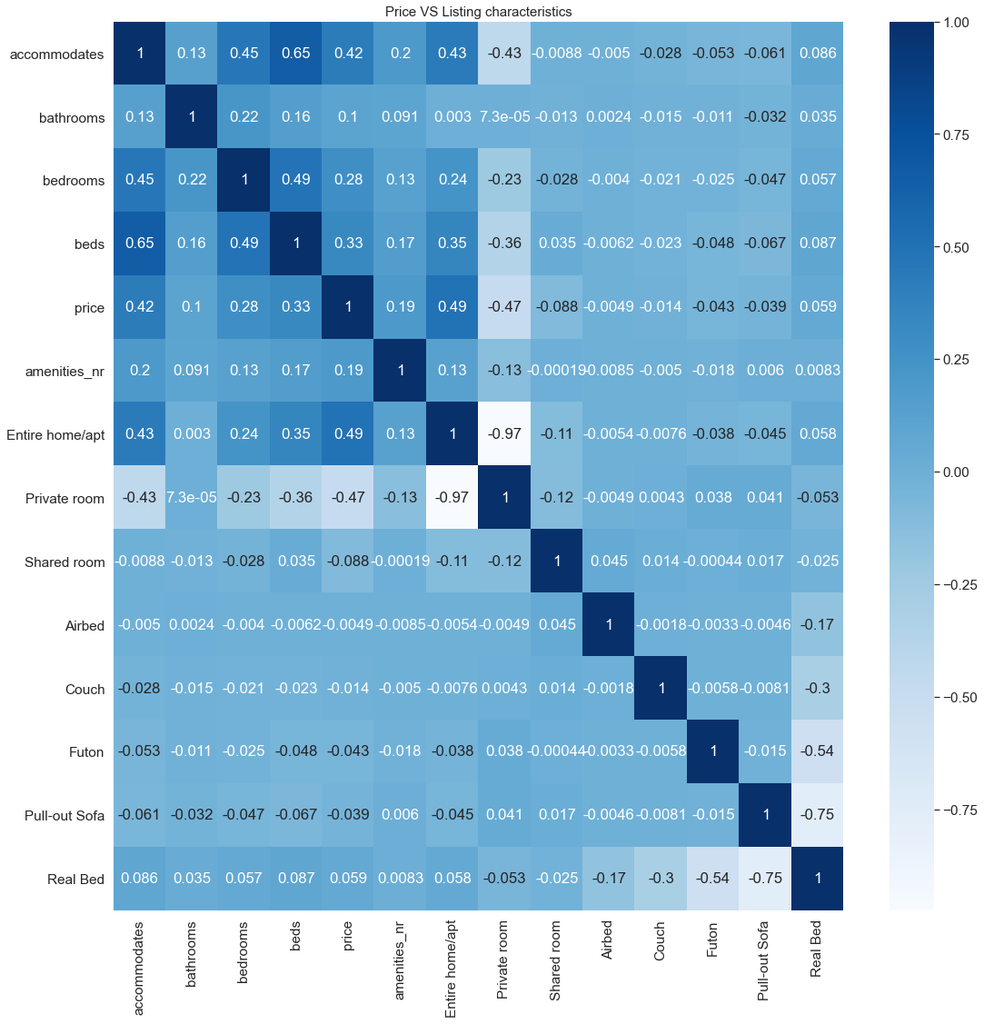

```python
plot_correlation_matrix(dfPricesListingTypes)
```

According to the heatmap, the column 'price' shows a slight degree of correlation with only a few columns in the dataframe. In particular, it shows slight positive correlation with both 'accommodates' and 'Entire home/apt', and a slight negative correlation with 'Private room'.

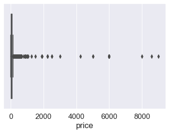

```python
sns.boxplot(x=dfPricesListingTypes['price'])
```

The boxplot shows the existence of some outliers.

So, basing on the mean and the standard deviation values, two border limits are computed.

```python
def get_outliers_limits(df_column, factor):
    upper_lim = df_column.mean () + df_column.std () * factor

    lower_lim = df_column.mean () - df_column.std () * factor

    return upper_lim, lower_lim
```

```python
upperLim, lowerLim = get_outliers_limits(dfPricesListingTypes['price'], 3)

print("upper_lim:", upperLim)
print("lower_lim:", lowerLim)
```

```
upper_lim: 728.8131181573846
lower_lim: -594.6431288373418
```

Since the values in the column 'price' are always positive, the lower limit can be discarded.

```python
dfPricesListingTypesWithoutOutliers = \
    dfPricesListingTypes[dfPricesListingTypes['price'] < upperLim]

print('Number of outliers removed:',
      dfPricesListingTypes.shape[0] - dfPricesListingTypesWithoutOutliers.shape[0])
```

```
Number of outliers removed: 51
```

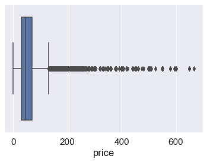

```python
sns.boxplot(x=dfPricesListingTypesWithoutOutliers['price'])
```

### 8.4 Regression

In order to make predictions on the column 'price', a regression model can be built-up.

#### 8.4.1 Regression with numerical features

Firstly, it is possible to start building the regression model by using just the features that were initially provided as numerical.

```python
dfPricesNumericalListingTypes = \
    dfPricesListingTypesWithoutOutliers[['accommodates', 'bathrooms', 'bedrooms',
                                         'beds', 'price']]

dfPricesNumericalListingTypes.head()
```

|  | accommodates | bathrooms | bedrooms | beds | price |
| --- | --- | --- | --- | --- | --- |
| 0 | 3 | 1.0 | 1.0 | 2.0 | 60.0 |
| 1 | 2 | 1.0 | 1.0 | 1.0 | 17.0 |
| 2 | 4 | 1.0 | 1.0 | 2.0 | 90.0 |
| 3 | 2 | 1.0 | 1.0 | 1.0 | 26.0 |
| 4 | 2 | 1.0 | 1.0 | 2.0 | 42.0 |

Once the numerical features are selected, the heatmap concerning the correlation between them can be shown.

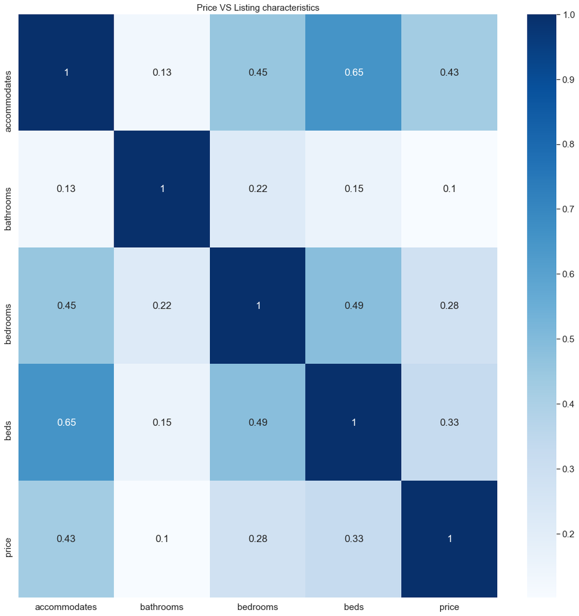

```python
plot_correlation_matrix(dfPricesNumericalListingTypes)
```

Before the creation of the regression model, the available data-points should be split into train and test data.

```python
from sklearn import linear_model
from sklearn.model_selection import train_test_split

def get_train_test(train_data, test_data):
    train_x, test_x, train_y, test_y = train_test_split(
        train_data, test_data, test_size=0.3, shuffle=True, random_state=42)

    return train_x, test_x, train_y, test_y
```

```python
trainXNumerical, testXNumerical, trainYNumerical, testYNumerical = \
    get_train_test(dfPricesNumericalListingTypes.iloc[:,:4],
                   dfPricesNumericalListingTypes['price'])

trainXNumerical.head()
```

|  | accommodates | bathrooms | bedrooms | beds |
| --- | --- | --- | --- | --- |
| 13156 | 3 | 1.0 | 1.0 | 2.0 |
| 20814 | 2 | 1.0 | 1.0 | 1.0 |
| 2233 | 1 | 1.5 | 1.0 | 1.0 |
| 12040 | 6 | 1.0 | 2.0 | 4.0 |
| 18754 | 2 | 1.0 | 0.0 | 1.0 |

Once the data has been split, a linear regression model can be built-up and trained.

```python
linearRegressionNumerical = linear_model.LinearRegression()
linearRegressionNumerical.fit(trainXNumerical, trainYNumerical)
```

```
LinearRegression()
```

Finally, the values concerning the model coefficients and the model accuracy can be shown. The score coefficient, representing the accuracy of the model, is the coefficient of determination R^2 of the prediction. It is computed as

$$ R^2 = 1 - u/v $$

where u is the residual sum of squares and v is the total sum of squares.

```python
print('Coefficients:', linearRegressionNumerical.coef_)
print('Intercept:', linearRegressionNumerical.intercept_)
print('Score:', linearRegressionNumerical.score(testXNumerical, testYNumerical))
```

```
Coefficients: [14.84855927 15.0254551  12.74297785 -2.26908704]
Intercept: -7.900577989084695
Score: 0.31616279461219277
```

Looking at the score, the regression model does not reach a good value of accuracy.

It is also possible to plot both the training and the test errors.

```python
def plot_regression_error(regression_model, train_x, train_y, test_x, test_y):

    ## plotting residual errors in training data
    plt.scatter(regression_model.predict(train_x),
                regression_model.predict(train_x) - train_y,
                color = "green", s = 10, label = 'Train data')

    ## plotting residual errors in test data
    plt.scatter(regression_model.predict(test_x),
                regression_model.predict(test_x) - test_y,
                color = "blue", s = 10, label = 'Test data')

    ## plotting legend
    plt.legend(loc = 'upper right')

    ## plot title
    plt.title("Residual errors")

    ## method call for showing the plot
    plt.show()
```

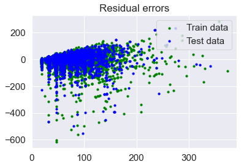

```python
plot_regression_error(linearRegressionNumerical, trainXNumerical, trainYNumerical,
                      testXNumerical, testYNumerical)
```

#### 8.4.2 Regression with all the features

Looking at the results obtained by using only the numerical features, it is possible to build the regression model with all the features.

The performed steps are the same as before.

```python
dfPricesAllListingTypes = dfPricesListingTypesWithoutOutliers.copy()
dfPricesAllListingTypes.head()
```

|  | accommodates | bathrooms | bedrooms | beds | price | amenities_nr | Entire home/apt | Private room | Shared room | Airbed | Couch | Futon | Pull-out Sofa | Real Bed |
| --- | --- | --- | --- | --- | --- | --- | --- | --- | --- | --- | --- | --- | --- | --- |
| 0 | 3 | 1.0 | 1.0 | 2.0 | 60.0 | 30 | 1 | 0 | 0 | 0 | 0 | 0 | 0 | 1 |
| 1 | 2 | 1.0 | 1.0 | 1.0 | 17.0 | 11 | 0 | 1 | 0 | 0 | 0 | 0 | 0 | 1 |
| 2 | 4 | 1.0 | 1.0 | 2.0 | 90.0 | 20 | 1 | 0 | 0 | 0 | 0 | 0 | 0 | 1 |
| 3 | 2 | 1.0 | 1.0 | 1.0 | 26.0 | 30 | 0 | 1 | 0 | 0 | 0 | 0 | 1 | 0 |
| 4 | 2 | 1.0 | 1.0 | 2.0 | 42.0 | 14 | 0 | 1 | 0 | 0 | 0 | 0 | 0 | 1 |

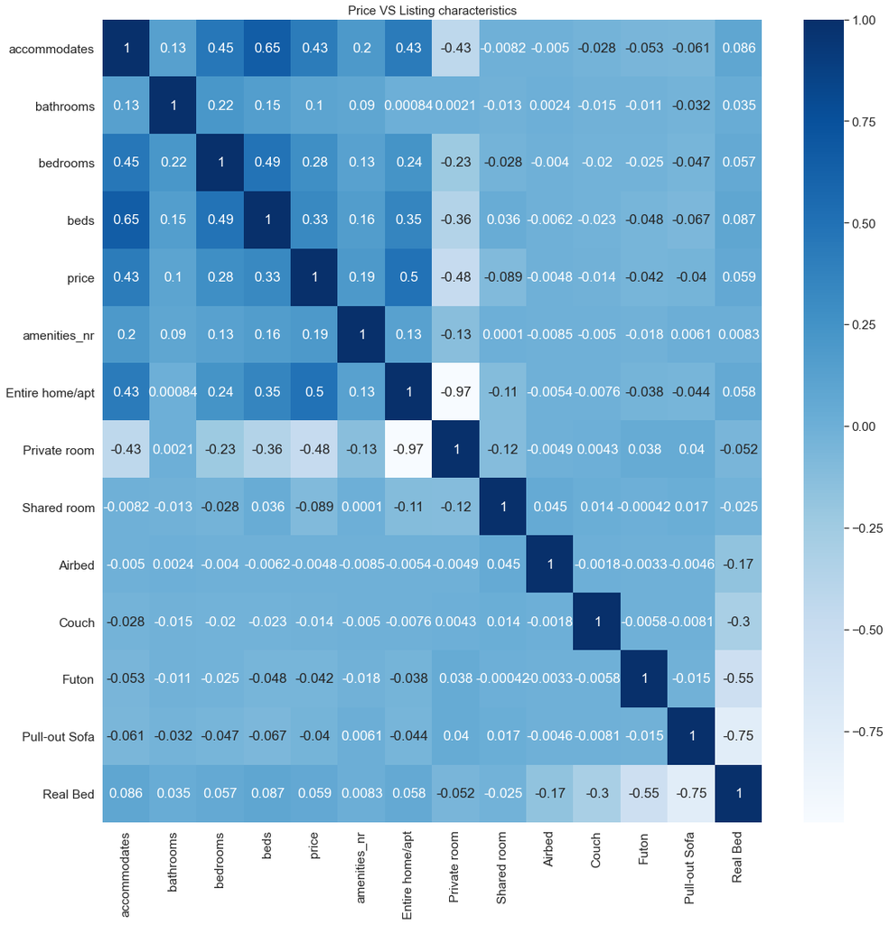

```python
plot_correlation_matrix(dfPricesAllListingTypes)
```

```python
trainX, testX, trainY, testY = get_train_test(
    dfPricesAllListingTypes.loc[
        :, dfPricesAllListingTypes.columns != 'price'],
    dfPricesAllListingTypes['price'])

trainX.head()
```

|  | accommodates | bathrooms | bedrooms | beds | amenities_nr | Entire home/apt | Private room | Shared room | Airbed | Couch | Futon | Pull-out Sofa | Real Bed |
| --- | --- | --- | --- | --- | --- | --- | --- | --- | --- | --- | --- | --- | --- |
| 13156 | 3 | 1.0 | 1.0 | 2.0 | 20 | 1 | 0 | 0 | 0 | 0 | 0 | 0 | 1 |
| 20814 | 2 | 1.0 | 1.0 | 1.0 | 10 | 1 | 0 | 0 | 0 | 0 | 0 | 0 | 1 |
| 2233 | 1 | 1.5 | 1.0 | 1.0 | 11 | 0 | 1 | 0 | 0 | 0 | 0 | 0 | 1 |
| 12040 | 6 | 1.0 | 2.0 | 4.0 | 12 | 1 | 0 | 0 | 0 | 0 | 0 | 0 | 1 |
| 18754 | 2 | 1.0 | 0.0 | 1.0 | 15 | 1 | 0 | 0 | 0 | 0 | 0 | 0 | 1 |

```python
linearRegression = linear_model.LinearRegression()
linearRegression.fit(trainX, trainY)
```

```
LinearRegression()
```

```python
print('Coefficients:', linearRegression.coef_)
print('Intercept:', linearRegression.intercept_)
print('Score:', linearRegression.score(testX, testY))
```

```
Coefficients: [ 10.46209988  17.37034387  12.64907199  -1.72519179   0.49904722
  18.92306887  -3.62183463 -15.30123424  -3.72788548   6.78304583
  -3.41430076  -0.79903079   1.15817119]
Intercept: -16.227418633150307
Score: 0.3748417664305357
```

Looking at the score, the regression model reaches a better value of accuracy, but even in this case the results are not satisfactory.

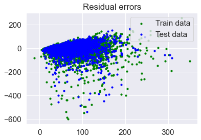

```python
plot_regression_error(linearRegression, trainX, trainY, testX, testY)
```

### 8.5 Classification

Instead of trying to predict the column 'price' with a regression, it is also possible to transform it into a categorical feature and try to predict the category.

#### 8.5.1 Transformation of price for classification

The 'price' feature needs to be binned in order to generate categorical values.

```python
dfPricesAllListingTypes['price'].describe()
```

```
count    22421.000000
mean        58.543954
std         47.424146
min          0.000000
25%         30.000000
50%         45.000000
75%         70.000000
max        666.000000
Name: price, dtype: float64
```

In order to obtain an optimized binning of the feature, a clustering technique on the feature is used.

```
inertia_ 50423691.93300878
inertia_ 22749705.231198255
inertia_ 11986753.435834724
inertia_ 7141239.833383507
inertia_ 4652318.868546425
inertia_ 3221570.323364333
inertia_ 2451968.1154055973
inertia_ 1906398.4968592583
inertia_ 1464994.142685093
inertia_ 1154390.0543708012
```

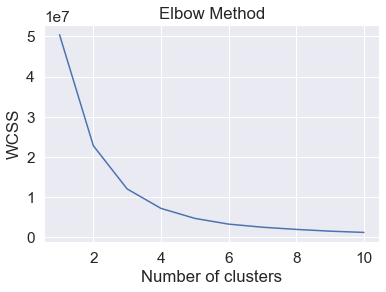

```python
kmeans_elbow_method(dfPricesAllListingTypes['price'].values.reshape(-1,1))
```

```python
rangeClusters = enumerate([2,3,4,5])
kmeans_silhouette(dfPricesAllListingTypes['price'].values.reshape(-1,1), rangeClusters)
```

```
For n_clusters = 2 The computed average silhouette_score is : 0.7550302861253866
For n_clusters = 3 The computed average silhouette_score is : 0.6405431657017057
For n_clusters = 4 The computed average silhouette_score is : 0.6267372844606797
For n_clusters = 5 The computed average silhouette_score is : 0.5794091287827978
```

The value n_clusters = 3 is chosen because it allows to have a more flexible classification.

```python
kmeansModelPrice = KMeans(n_clusters=3, max_iter=1000, random_state=42, n_init=50)
kmeansModelPrice.fit(dfPricesAllListingTypes['price'].values.reshape(-1,1))
```

```
KMeans(max_iter=1000, n_clusters=3, n_init=50, random_state=42)
```

```python
kmeansModelPrice.cluster_centers_
```

```
array([[ 96.5813074 ],
       [ 38.70096719],
       [270.82518797]])
```

Looking at the model clusters, it is possible to assign the cluster index to each binning value.

```python
lowClusterIndex = 1
mediumClusterIndex = 0
```

#### 8.5.2 Classification with numerical features

Firstly, it is possible to start building the classification model by using just the features that were initially provided as numerical.

```python
dfPricesNumericalListingTypes['price_cluster'] = kmeansModelPrice.predict(
    dfPricesNumericalListingTypes['price'].values.reshape(-1,1))

dfPricesNumericalListingTypes['price_cluster'] = \
    dfPricesNumericalListingTypes['price_cluster'].apply(
        lambda x: 'low' if x==lowClusterIndex else
            'medium' if x==mediumClusterIndex else 'high')

dfPricesNumericalListingTypes.head()
```

[output not shown]

|  | accommodates | bathrooms | bedrooms | beds | price | price_cluster |
| --- | --- | --- | --- | --- | --- | --- |
| 0 | 3 | 1.0 | 1.0 | 2.0 | 60.0 | low |
| 1 | 2 | 1.0 | 1.0 | 1.0 | 17.0 | low |
| 2 | 4 | 1.0 | 1.0 | 2.0 | 90.0 | medium |
| 3 | 2 | 1.0 | 1.0 | 1.0 | 26.0 | low |
| 4 | 2 | 1.0 | 1.0 | 2.0 | 42.0 | low |

Before the creation of the classification model, the available data-points should be split into train and test data.

```python
trainXNumericalClass, testXNumericalClass, trainYNumericalClass, testYNumericalClass = \
    get_train_test(dfPricesNumericalListingTypes.iloc[:,:4],
                   dfPricesNumericalListingTypes['price_cluster'])

trainXNumericalClass.head()
```

|  | accommodates | bathrooms | bedrooms | beds |
| --- | --- | --- | --- | --- |
| 13156 | 3 | 1.0 | 1.0 | 2.0 |
| 20814 | 2 | 1.0 | 1.0 | 1.0 |
| 2233 | 1 | 1.5 | 1.0 | 1.0 |
| 12040 | 6 | 1.0 | 2.0 | 4.0 |
| 18754 | 2 | 1.0 | 0.0 | 1.0 |

Once the data has been split, a decision tree classifier can be built-up and trained.

```python
from sklearn.tree import DecisionTreeClassifier

decisionTreeNumerical = DecisionTreeClassifier()
decisionTreeNumerical.fit(trainXNumericalClass, trainYNumericalClass)
```

```
DecisionTreeClassifier()
```

Then, the model is used in order to generate the predictions.

```python
predictionsNumerical = decisionTreeNumerical.predict(testXNumericalClass)
```

Once the predictions have been generated, it is possible to evaluate the model.

```python
from sklearn.metrics import classification_report
```

```python
print(confusion_matrix(testYNumericalClass, predictionsNumerical))
print(classification_report(testYNumericalClass, predictionsNumerical))
```

```
[[  31   42   89]
 [   7 4688  252]
 [  27 1040  551]]
              precision    recall  f1-score   support

        high       0.48      0.19      0.27       162
         low       0.81      0.95      0.87      4947
      medium       0.62      0.34      0.44      1618

    accuracy                           0.78      6727
   macro avg       0.64      0.49      0.53      6727
weighted avg       0.76      0.78      0.76      6727
```

The classification with only the numerical features globally shows good results, with an accuracy of 78%. In particular, the model shows very good values for the "low" classification, but poor results in the classification of "medium" and "high" data-points.

#### 8.5.3 Classification with all the features

Looking at the results obtained by using only the numerical features, it is possible to build the classification model with all the features.

The performed steps are the same as before.

```python
dfPricesAllListingTypes['price_cluster'] = kmeansModelPrice.predict(
    dfPricesAllListingTypes['price'].values.reshape(-1,1))

dfPricesAllListingTypes['price_cluster'] = \
    dfPricesAllListingTypes['price_cluster'].apply(
        lambda x: 'low' if x==lowClusterIndex else
            'medium' if x==mediumClusterIndex else 'high')

dfPricesAllListingTypes.head()
```

|  | accommodates | bathrooms | bedrooms | beds | price | amenities_nr | Entire home/apt | Private room | Shared room | Airbed | Couch | Futon | Pull-out Sofa | Real Bed | price_cluster |
| --- | --- | --- | --- | --- | --- | --- | --- | --- | --- | --- | --- | --- | --- | --- | --- |
| 0 | 3 | 1.0 | 1.0 | 2.0 | 60.0 | 30 | 1 | 0 | 0 | 0 | 0 | 0 | 0 | 1 | low |
| 1 | 2 | 1.0 | 1.0 | 1.0 | 17.0 | 11 | 0 | 1 | 0 | 0 | 0 | 0 | 0 | 1 | low |
| 2 | 4 | 1.0 | 1.0 | 2.0 | 90.0 | 20 | 1 | 0 | 0 | 0 | 0 | 0 | 0 | 1 | medium |
| 3 | 2 | 1.0 | 1.0 | 1.0 | 26.0 | 30 | 0 | 1 | 0 | 0 | 0 | 0 | 1 | 0 | low |
| 4 | 2 | 1.0 | 1.0 | 2.0 | 42.0 | 14 | 0 | 1 | 0 | 0 | 0 | 0 | 0 | 1 | low |

```python
trainXClass, testXClass, trainYClass, testYClass = get_train_test(
    dfPricesAllListingTypes.drop(columns=['price', 'price_cluster']),
    dfPricesAllListingTypes['price_cluster'])

trainXClass.head()
```

|  | accommodates | bathrooms | bedrooms | beds | amenities_nr | Entire home/apt | Private room | Shared room | Airbed | Couch | Futon | Pull-out Sofa | Real Bed |
| --- | --- | --- | --- | --- | --- | --- | --- | --- | --- | --- | --- | --- | --- |
| 13156 | 3 | 1.0 | 1.0 | 2.0 | 20 | 1 | 0 | 0 | 0 | 0 | 0 | 0 | 1 |
| 20814 | 2 | 1.0 | 1.0 | 1.0 | 10 | 1 | 0 | 0 | 0 | 0 | 0 | 0 | 1 |
| 2233 | 1 | 1.5 | 1.0 | 1.0 | 11 | 0 | 1 | 0 | 0 | 0 | 0 | 0 | 1 |
| 12040 | 6 | 1.0 | 2.0 | 4.0 | 12 | 1 | 0 | 0 | 0 | 0 | 0 | 0 | 1 |
| 18754 | 2 | 1.0 | 0.0 | 1.0 | 15 | 1 | 0 | 0 | 0 | 0 | 0 | 0 | 1 |

```python
decisionTree = DecisionTreeClassifier()
decisionTree.fit(trainXClass, trainYClass)
```

```
DecisionTreeClassifier()
```

```python
predictions = decisionTree.predict(testXClass)
```

```python
print(confusion_matrix(testYClass, predictions))
print(classification_report(testYClass, predictions))
```

```
[[  40   51   71]
 [  16 4532  399]
 [  68  978  572]]
              precision    recall  f1-score   support

        high       0.32      0.25      0.28       162
         low       0.81      0.92      0.86      4947
      medium       0.55      0.35      0.43      1618

    accuracy                           0.76      6727
   macro avg       0.56      0.51      0.52      6727
weighted avg       0.74      0.76      0.74      6727
```

Even in this case, the classification with all the features globally shows some good results, that are only slightly lower than using only the numerical features. In particular, the model shows a global accuracy of 76%, very good values for the "low" classification, but poor results in the classification of "medium" and "high" data-points.

### 8.6 Outliers removal with new threshold

```python
upperLim2, lowerLim2 = get_outliers_limits(dfPricesListingTypes['price'], 2)

print("upper_lim:", upperLim2)
print("lower_lim:", lowerLim2)
```

```
upper_lim: 508.23707699159684
lower_lim: -374.0670876715541
```

Since the values in the column 'price' are always positive, the lower limit can be discarded.

```python
dfPricesListingTypesWithoutOutliers2 = \
    dfPricesListingTypes[dfPricesListingTypes['price'] < upperLim2]

print('Number of outliers removed:',
      dfPricesListingTypes.shape[0] - dfPricesListingTypesWithoutOutliers2.shape[0])
```

```
Number of outliers removed: 70
```

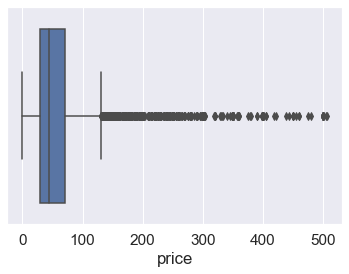

```python
sns.boxplot(x=dfPricesListingTypesWithoutOutliers2['price'])
```

#### 8.6.1 Regression with numerical features and new threshold

The performed steps are always the same.

```python
dfPricesNumericalListingTypes2 = \
    dfPricesListingTypesWithoutOutliers2[['accommodates', 'bathrooms', 'bedrooms',
                                         'beds', 'price']]

dfPricesNumericalListingTypes2.head()
```

|  | accommodates | bathrooms | bedrooms | beds | price |
| --- | --- | --- | --- | --- | --- |
| 0 | 3 | 1.0 | 1.0 | 2.0 | 60.0 |
| 1 | 2 | 1.0 | 1.0 | 1.0 | 17.0 |
| 2 | 4 | 1.0 | 1.0 | 2.0 | 90.0 |
| 3 | 2 | 1.0 | 1.0 | 1.0 | 26.0 |
| 4 | 2 | 1.0 | 1.0 | 2.0 | 42.0 |

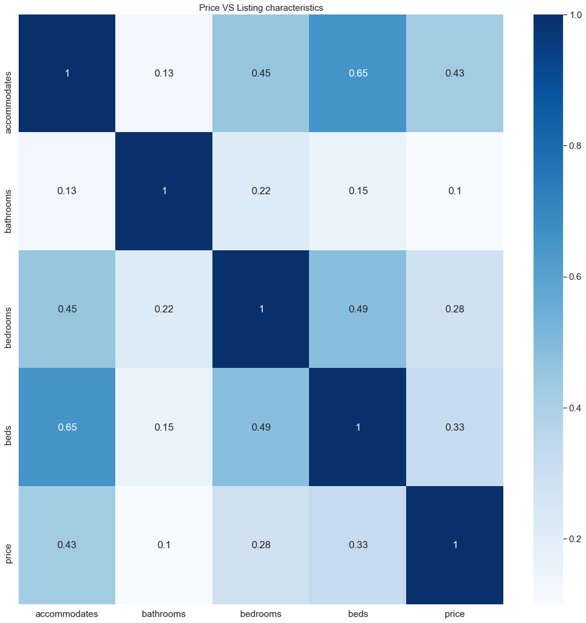

```python
plot_correlation_matrix(dfPricesNumericalListingTypes2)
```

```python
trainXNumerical2, testXNumerical2, trainYNumerical2, testYNumerical2 = \
    get_train_test(dfPricesNumericalListingTypes2.iloc[:,:4],
                   dfPricesNumericalListingTypes2['price'])

trainXNumerical2.head()
```

|  | accommodates | bathrooms | bedrooms | beds |
| --- | --- | --- | --- | --- |
| 2379 | 4 | 1.0 | 2.0 | 2.0 |
| 10645 | 2 | 1.0 | 1.0 | 1.0 |
| 9199 | 5 | 1.5 | 2.0 | 3.0 |
| 675 | 2 | 1.0 | 1.0 | 2.0 |
| 8444 | 1 | 1.0 | 1.0 | 1.0 |

```python
linearRegressionNumerical2 = linear_model.LinearRegression()
linearRegressionNumerical2.fit(trainXNumerical2, trainYNumerical2)
```

```
LinearRegression()
```

```python
print('Coefficients:', linearRegressionNumerical2.coef_)
print('Intercept:', linearRegressionNumerical2.intercept_)
print('Score:', linearRegressionNumerical2.score(testXNumerical2, testYNumerical2))
```

```
Coefficients: [14.66947589 13.47069656 12.30341242 -2.54472805]
Intercept: -5.164348478815668
Score: 0.3550238476894051
```

With respect to the results obtained by using more data-points, the model accuracy is slightly increased. However, the results are still not satisfactory.

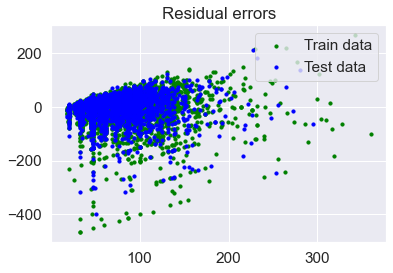

```python
plot_regression_error(linearRegressionNumerical2, trainXNumerical2, trainYNumerical2,
                      testXNumerical2, testYNumerical2)
```

#### 8.6.2 Regression with all the features and new threshold

```python
dfPricesAllListingTypes2 = dfPricesListingTypesWithoutOutliers2.copy()
dfPricesAllListingTypes2.head()
```

|  | accommodates | bathrooms | bedrooms | beds | price | amenities_nr | Entire home/apt | Private room | Shared room | Airbed | Couch | Futon | Pull-out Sofa | Real Bed |
| --- | --- | --- | --- | --- | --- | --- | --- | --- | --- | --- | --- | --- | --- | --- |
| 0 | 3 | 1.0 | 1.0 | 2.0 | 60.0 | 30 | 1 | 0 | 0 | 0 | 0 | 0 | 0 | 1 |
| 1 | 2 | 1.0 | 1.0 | 1.0 | 17.0 | 11 | 0 | 1 | 0 | 0 | 0 | 0 | 0 | 1 |
| 2 | 4 | 1.0 | 1.0 | 2.0 | 90.0 | 20 | 1 | 0 | 0 | 0 | 0 | 0 | 0 | 1 |
| 3 | 2 | 1.0 | 1.0 | 1.0 | 26.0 | 30 | 0 | 1 | 0 | 0 | 0 | 0 | 1 | 0 |
| 4 | 2 | 1.0 | 1.0 | 2.0 | 42.0 | 14 | 0 | 1 | 0 | 0 | 0 | 0 | 0 | 1 |

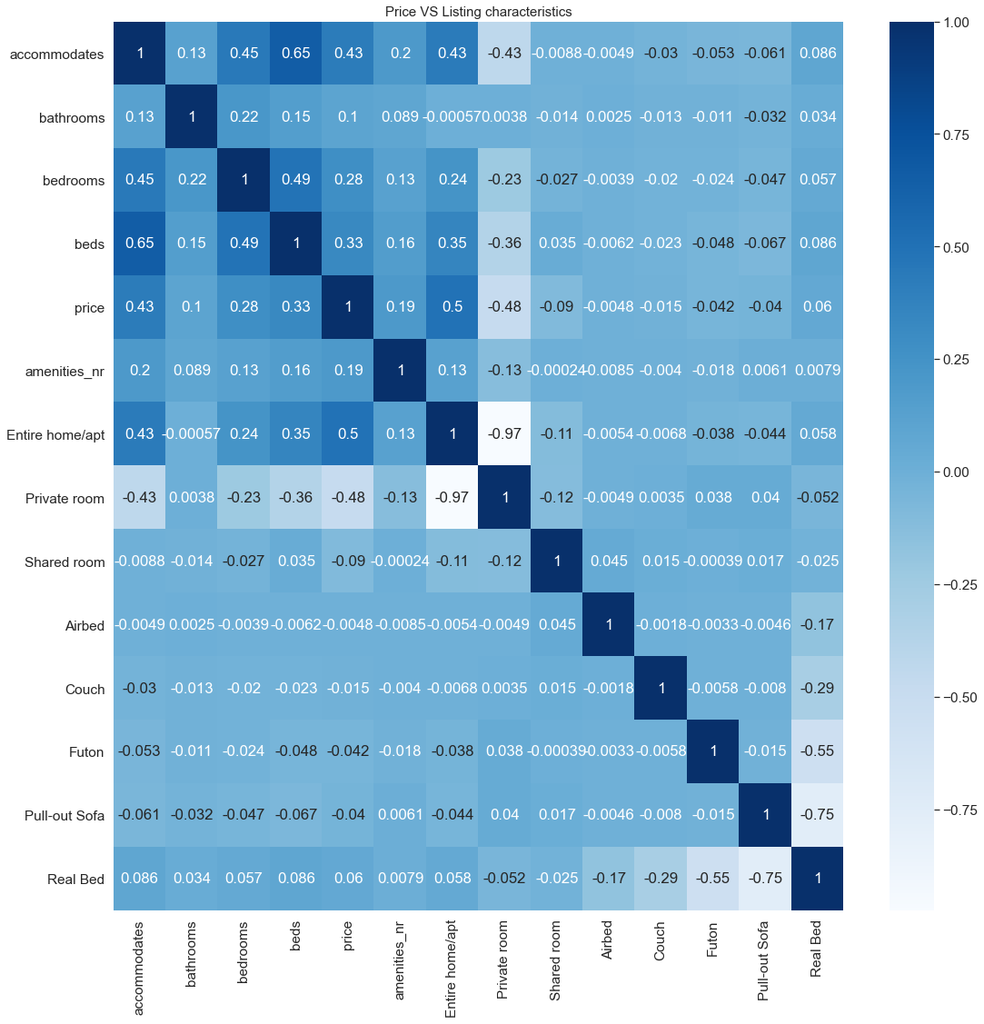

```python
plot_correlation_matrix(dfPricesAllListingTypes2)
```

```python
trainX2, testX2, trainY2, testY2 = get_train_test(
    dfPricesAllListingTypes2.loc[
        :, dfPricesAllListingTypes2.columns != 'price'],
    dfPricesAllListingTypes2['price'])

trainX2.head()
```

|  | accommodates | bathrooms | bedrooms | beds | amenities_nr | Entire home/apt | Private room | Shared room | Airbed | Couch | Futon | Pull-out Sofa | Real Bed |
| --- | --- | --- | --- | --- | --- | --- | --- | --- | --- | --- | --- | --- | --- |
| 2379 | 4 | 1.0 | 2.0 | 2.0 | 11 | 1 | 0 | 0 | 0 | 0 | 0 | 0 | 1 |
| 10645 | 2 | 1.0 | 1.0 | 1.0 | 14 | 1 | 0 | 0 | 0 | 0 | 0 | 0 | 1 |
| 9199 | 5 | 1.5 | 2.0 | 3.0 | 7 | 1 | 0 | 0 | 0 | 0 | 0 | 0 | 1 |
| 675 | 2 | 1.0 | 1.0 | 2.0 | 24 | 0 | 1 | 0 | 0 | 0 | 1 | 0 | 0 |
| 8444 | 1 | 1.0 | 1.0 | 1.0 | 12 | 0 | 1 | 0 | 0 | 0 | 0 | 0 | 1 |

```python
linearRegression2 = linear_model.LinearRegression()
linearRegression2.fit(trainX2, trainY2)
```

```
LinearRegression()
```

```python
print('Coefficients:', linearRegression2.coef_)
print('Intercept:', linearRegression2.intercept_)
print('Score:', linearRegression2.score(testX2, testY2))
```

```
Coefficients: [ 10.38648478  16.00439732  12.03750052  -1.93935208   0.46919188
  19.27135434  -3.2354611  -16.03589325   7.01417174  -3.06048731
  -4.10940551  -0.383755     0.53947608]
Intercept: -13.088596675787272
Score: 0.4250146973044623
```

Even in this case, the accuracy value is slightly greater than the one obtained by considering a higher number of data-points, but still not enough in order to make reliable predictions.

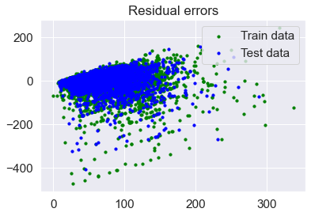

```python
plot_regression_error(linearRegression2, trainX2, trainY2, testX2, testY2)
```

#### 8.6.3 Transformation of price with new threshold for classification

It is also possible to use the dataframe with more outliers removed in order to create a new classification model and check its performance.

Even in this case, the performed steps are always the same.

```python
dfPricesAllListingTypes2['price'].describe()
```

```
count    22402.000000
mean        58.094456
std         44.843976
min          0.000000
25%         30.000000
50%         45.000000
75%         70.000000
max        506.000000
Name: price, dtype: float64
```

```
inertia_ 45048012.13141702
inertia_ 19474539.282685254
inertia_ 9888890.89284995
inertia_ 5951239.391527219
inertia_ 4017791.5190839022
inertia_ 2686837.9447985156
inertia_ 2057194.3297260054
inertia_ 1542785.609180676
inertia_ 1231264.450848482
inertia_ 1010421.0352468448
```

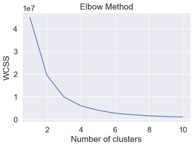

```python
kmeans_elbow_method(dfPricesAllListingTypes2['price'].values.reshape(-1,1))
```

```python
rangeClusters = enumerate([2,3,4,5])
kmeans_silhouette(dfPricesAllListingTypes2['price'].values.reshape(-1,1),
                  rangeClusters)
```

```
For n_clusters = 2 The computed average silhouette_score is : 0.749608218813753
For n_clusters = 3 The computed average silhouette_score is : 0.6337545751486906
For n_clusters = 4 The computed average silhouette_score is : 0.6133501215910729
For n_clusters = 5 The computed average silhouette_score is : 0.576614801709885
```

The value n_clusters = 3 is chosen because it allows to have a more flexible classification.

```python
kmeansModelPrice2 = KMeans(n_clusters=3, max_iter=1000, random_state=42, n_init=50)
kmeansModelPrice2.fit(dfPricesAllListingTypes2['price'].values.reshape(-1,1))
```

```
KMeans(max_iter=1000, n_clusters=3, n_init=50, random_state=42)
```

```python
kmeansModelPrice2.cluster_centers_
```

```
array([[ 38.63498589],
       [ 95.12547667],
       [247.74371859]])
```

```python
lowClusterIndex2 = 0
mediumClusterIndex2 = 1
```

#### 8.6.4 Classification with numerical features and new threshold

```python
dfPricesNumericalListingTypes2['price_cluster'] = kmeansModelPrice2.predict(
    dfPricesNumericalListingTypes2['price'].values.reshape(-1,1))

dfPricesNumericalListingTypes2['price_cluster'] = \
    dfPricesNumericalListingTypes2['price_cluster'].apply(
        lambda x: 'low' if x==lowClusterIndex2 else
            'medium' if x==mediumClusterIndex2 else 'high')

dfPricesNumericalListingTypes2.head()
```

[output not shown]

|  | accommodates | bathrooms | bedrooms | beds | price | price_cluster |
| --- | --- | --- | --- | --- | --- | --- |
| 0 | 3 | 1.0 | 1.0 | 2.0 | 60.0 | low |
| 1 | 2 | 1.0 | 1.0 | 1.0 | 17.0 | low |
| 2 | 4 | 1.0 | 1.0 | 2.0 | 90.0 | medium |
| 3 | 2 | 1.0 | 1.0 | 1.0 | 26.0 | low |
| 4 | 2 | 1.0 | 1.0 | 2.0 | 42.0 | low |

```python
trainXNumericalClass2, testXNumericalClass2, trainYNumericalClass2, testYNumericalClass2 = \
    get_train_test(dfPricesNumericalListingTypes2.iloc[:,:4],
                   dfPricesNumericalListingTypes2['price_cluster'])

trainXNumericalClass2.head()
```

|  | accommodates | bathrooms | bedrooms | beds |
| --- | --- | --- | --- | --- |
| 2379 | 4 | 1.0 | 2.0 | 2.0 |
| 10645 | 2 | 1.0 | 1.0 | 1.0 |
| 9199 | 5 | 1.5 | 2.0 | 3.0 |
| 675 | 2 | 1.0 | 1.0 | 2.0 |
| 8444 | 1 | 1.0 | 1.0 | 1.0 |

```python
decisionTreeNumerical2 = DecisionTreeClassifier()
decisionTreeNumerical2.fit(trainXNumericalClass2, trainYNumericalClass2)
```

```
DecisionTreeClassifier()
```

```python
predictionsNumerical2 = decisionTreeNumerical2.predict(testXNumericalClass2)
```

```python
print(confusion_matrix(testYNumericalClass2, predictionsNumerical2))
print(classification_report(testYNumericalClass2, predictionsNumerical2))
```

```
[[  40   45   87]
 [   7 4685  237]
 [  34 1059  527]]
              precision    recall  f1-score   support

        high       0.49      0.23      0.32       172
         low       0.81      0.95      0.87      4929
      medium       0.62      0.33      0.43      1620

    accuracy                           0.78      6721
   macro avg       0.64      0.50      0.54      6721
weighted avg       0.76      0.78      0.75      6721
```

Even in this case, the classification with only the numerical features globally shows good results, with an accuracy of 78%. The results are comparable to the ones previously-obtained.

#### 8.6.5 Classification with all the features and new threshold

```python
dfPricesAllListingTypes2['price_cluster'] = kmeansModelPrice2.predict(
    dfPricesAllListingTypes2['price'].values.reshape(-1,1))

dfPricesAllListingTypes2['price_cluster'] = \
    dfPricesAllListingTypes2['price_cluster'].apply(
        lambda x: 'low' if x==lowClusterIndex2 else
            'medium' if x==mediumClusterIndex2 else 'high')

dfPricesAllListingTypes2.head()
```

|  | accommodates | bathrooms | bedrooms | beds | price | amenities_nr | Entire home/apt | Private room | Shared room | Airbed | Couch | Futon | Pull-out Sofa | Real Bed | price_cluster |
| --- | --- | --- | --- | --- | --- | --- | --- | --- | --- | --- | --- | --- | --- | --- | --- |
| 0 | 3 | 1.0 | 1.0 | 2.0 | 60.0 | 30 | 1 | 0 | 0 | 0 | 0 | 0 | 0 | 1 | low |
| 1 | 2 | 1.0 | 1.0 | 1.0 | 17.0 | 11 | 0 | 1 | 0 | 0 | 0 | 0 | 0 | 1 | low |
| 2 | 4 | 1.0 | 1.0 | 2.0 | 90.0 | 20 | 1 | 0 | 0 | 0 | 0 | 0 | 0 | 1 | medium |
| 3 | 2 | 1.0 | 1.0 | 1.0 | 26.0 | 30 | 0 | 1 | 0 | 0 | 0 | 0 | 1 | 0 | low |
| 4 | 2 | 1.0 | 1.0 | 2.0 | 42.0 | 14 | 0 | 1 | 0 | 0 | 0 | 0 | 0 | 1 | low |

```python
trainXClass2, testXClass2, trainYClass2, testYClass2 = get_train_test(
    dfPricesAllListingTypes2.drop(columns=['price', 'price_cluster']),
    dfPricesAllListingTypes2['price_cluster'])

trainXClass2.head()
```

|  | accommodates | bathrooms | bedrooms | beds | amenities_nr | Entire home/apt | Private room | Shared room | Airbed | Couch | Futon | Pull-out Sofa | Real Bed |
| --- | --- | --- | --- | --- | --- | --- | --- | --- | --- | --- | --- | --- | --- |
| 2379 | 4 | 1.0 | 2.0 | 2.0 | 11 | 1 | 0 | 0 | 0 | 0 | 0 | 0 | 1 |
| 10645 | 2 | 1.0 | 1.0 | 1.0 | 14 | 1 | 0 | 0 | 0 | 0 | 0 | 0 | 1 |
| 9199 | 5 | 1.5 | 2.0 | 3.0 | 7 | 1 | 0 | 0 | 0 | 0 | 0 | 0 | 1 |
| 675 | 2 | 1.0 | 1.0 | 2.0 | 24 | 0 | 1 | 0 | 0 | 0 | 1 | 0 | 0 |
| 8444 | 1 | 1.0 | 1.0 | 1.0 | 12 | 0 | 1 | 0 | 0 | 0 | 0 | 0 | 1 |

```python
decisionTree2 = DecisionTreeClassifier()
decisionTree2.fit(trainXClass2, trainYClass2)
```

```
DecisionTreeClassifier()
```

```python
predictions2 = decisionTree2.predict(testXClass2)
```

```python
print(confusion_matrix(testYClass2, predictions2))
print(classification_report(testYClass2, predictions2))
```

```
[[  42   46   84]
 [  22 4518  389]
 [  71  944  605]]
              precision    recall  f1-score   support

        high       0.31      0.24      0.27       172
         low       0.82      0.92      0.87      4929
      medium       0.56      0.37      0.45      1620

    accuracy                           0.77      6721
   macro avg       0.56      0.51      0.53      6721
weighted avg       0.74      0.77      0.75      6721
```

Even in this case, the classification accuracy is comparable to the one obtained by using the dataframe containing more data-points.

### 8.7 Outliers removal with percentiles

The outliers can also be removed according to the percentiles.

```python
upperLim3 = dfPricesListingTypes['price'].quantile(.99) # Return value at the given quantile
lowerLim3 = dfPricesListingTypes['price'].quantile(.01)

print("upper_lim:", upperLim3)
print("lower_lim:", lowerLim3)
```

```
upper_lim: 269.0
lower_lim: 15.0
```

```python
dfPricesListingTypesWithoutOutliers3 = \
    dfPricesListingTypes[dfPricesListingTypes['price'] > lowerLim3]

dfPricesListingTypesWithoutOutliers3 = dfPricesListingTypesWithoutOutliers3[
    dfPricesListingTypesWithoutOutliers3['price'] < upperLim3]

print('Number of outliers removed:',
      dfPricesListingTypes.shape[0] - dfPricesListingTypesWithoutOutliers3.shape[0])
```

```
Number of outliers removed: 591
```

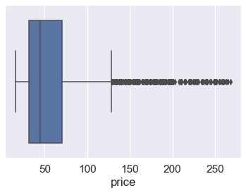

```python
sns.boxplot(x=dfPricesListingTypesWithoutOutliers3['price'])
```

#### 8.7.1 Regression with numerical features and percentiles

```python
dfPricesNumericalListingTypes3 = \
    dfPricesListingTypesWithoutOutliers3[['accommodates', 'bathrooms', 'bedrooms',
                                         'beds', 'price']]

dfPricesNumericalListingTypes3.head()
```

|  | accommodates | bathrooms | bedrooms | beds | price |
| --- | --- | --- | --- | --- | --- |
| 0 | 3 | 1.0 | 1.0 | 2.0 | 60.0 |
| 1 | 2 | 1.0 | 1.0 | 1.0 | 17.0 |
| 2 | 4 | 1.0 | 1.0 | 2.0 | 90.0 |
| 3 | 2 | 1.0 | 1.0 | 1.0 | 26.0 |
| 4 | 2 | 1.0 | 1.0 | 2.0 | 42.0 |

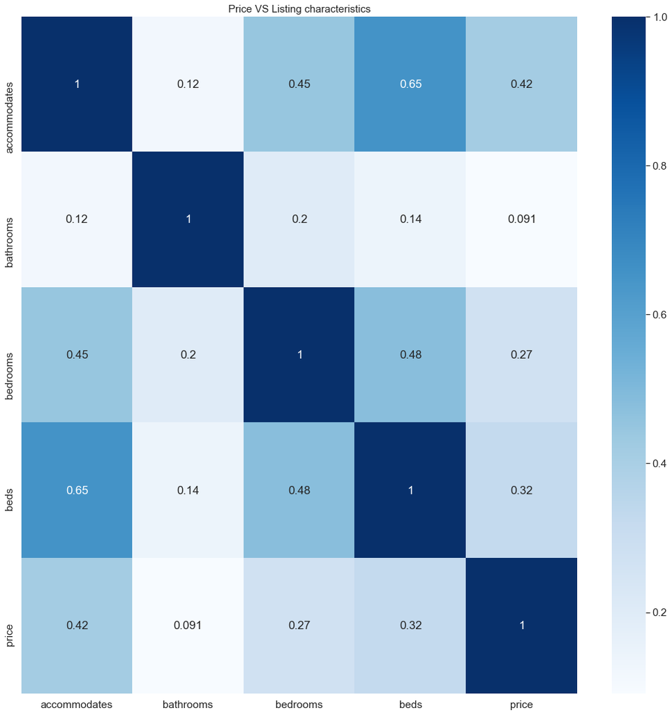

```python
plot_correlation_matrix(dfPricesNumericalListingTypes3)
```

```python
trainXNumerical3, testXNumerical3, trainYNumerical3, testYNumerical3 = \
    get_train_test(dfPricesNumericalListingTypes3.iloc[:,:4],
                   dfPricesNumericalListingTypes3['price'])

trainXNumerical3.head()
```

|  | accommodates | bathrooms | bedrooms | beds |
| --- | --- | --- | --- | --- |
| 6514 | 3 | 1.0 | 1.0 | 1.0 |
| 14983 | 4 | 1.0 | 2.0 | 2.0 |
| 16763 | 2 | 1.0 | 1.0 | 1.0 |
| 10096 | 2 | 1.5 | 1.0 | 1.0 |
| 6876 | 2 | 1.0 | 1.0 | 1.0 |

```python
linearRegressionNumerical3 = linear_model.LinearRegression()
linearRegressionNumerical3.fit(trainXNumerical3, trainYNumerical3)
```

```
LinearRegression()
```

```python
print('Coefficients:', linearRegressionNumerical3.coef_)
print('Intercept:', linearRegressionNumerical3.intercept_)
print('Score:', linearRegressionNumerical3.score(testXNumerical3, testYNumerical3))
```

```
Coefficients: [12.04264228  6.36102311  9.49262823 -0.67437339]
Intercept: 8.420414962219247
Score: 0.3618015718158146
```

With respect to the results obtained by the previous analysis, the model accuracy is slightly increased. However, the results are still not satisfactory.

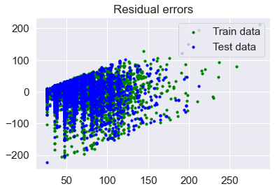

```python
plot_regression_error(linearRegressionNumerical3, trainXNumerical3, trainYNumerical3,
                      testXNumerical3, testYNumerical3)
```

#### 8.7.2 Regression with all the features and percentiles

```python
dfPricesAllListingTypes3 = dfPricesListingTypesWithoutOutliers3.copy()
dfPricesAllListingTypes3.head()
```

|  | accommodates | bathrooms | bedrooms | beds | price | amenities_nr | Entire home/apt | Private room | Shared room | Airbed | Couch | Futon | Pull-out Sofa | Real Bed |
| --- | --- | --- | --- | --- | --- | --- | --- | --- | --- | --- | --- | --- | --- | --- |
| 0 | 3 | 1.0 | 1.0 | 2.0 | 60.0 | 30 | 1 | 0 | 0 | 0 | 0 | 0 | 0 | 1 |
| 1 | 2 | 1.0 | 1.0 | 1.0 | 17.0 | 11 | 0 | 1 | 0 | 0 | 0 | 0 | 0 | 1 |
| 2 | 4 | 1.0 | 1.0 | 2.0 | 90.0 | 20 | 1 | 0 | 0 | 0 | 0 | 0 | 0 | 1 |
| 3 | 2 | 1.0 | 1.0 | 1.0 | 26.0 | 30 | 0 | 1 | 0 | 0 | 0 | 0 | 1 | 0 |
| 4 | 2 | 1.0 | 1.0 | 2.0 | 42.0 | 14 | 0 | 1 | 0 | 0 | 0 | 0 | 0 | 1 |

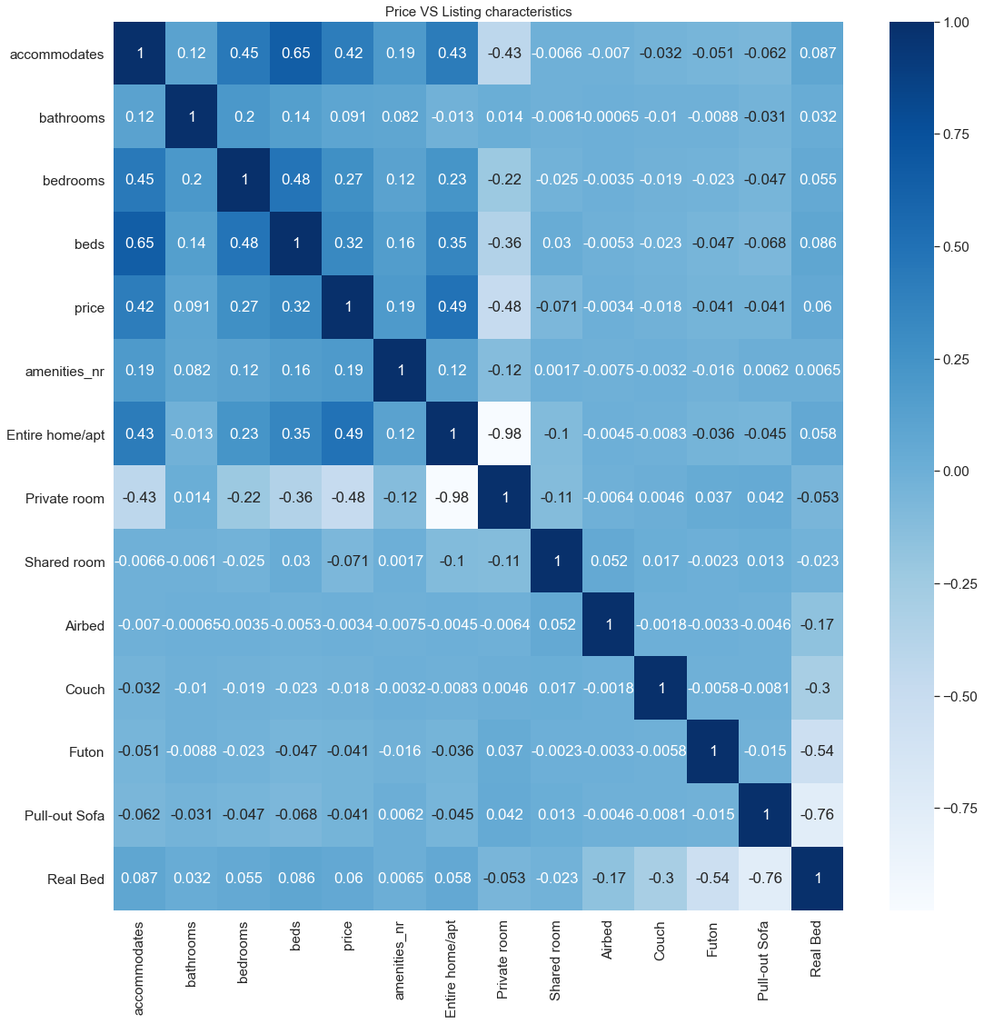

```python
plot_correlation_matrix(dfPricesAllListingTypes3)
```

```python
trainX3, testX3, trainY3, testY3 = get_train_test(
    dfPricesAllListingTypes3.loc[
        :, dfPricesAllListingTypes3.columns != 'price'],
    dfPricesAllListingTypes3['price'])

trainX3.head()
```

|  | accommodates | bathrooms | bedrooms | beds | amenities_nr | Entire home/apt | Private room | Shared room | Airbed | Couch | Futon | Pull-out Sofa | Real Bed |
| --- | --- | --- | --- | --- | --- | --- | --- | --- | --- | --- | --- | --- | --- |
| 6514 | 3 | 1.0 | 1.0 | 1.0 | 16 | 1 | 0 | 0 | 0 | 0 | 0 | 0 | 1 |
| 14983 | 4 | 1.0 | 2.0 | 2.0 | 14 | 1 | 0 | 0 | 0 | 0 | 0 | 0 | 1 |
| 16763 | 2 | 1.0 | 1.0 | 1.0 | 23 | 1 | 0 | 0 | 0 | 0 | 0 | 0 | 1 |
| 10096 | 2 | 1.5 | 1.0 | 1.0 | 16 | 0 | 1 | 0 | 0 | 0 | 0 | 0 | 1 |
| 6876 | 2 | 1.0 | 1.0 | 1.0 | 10 | 1 | 0 | 0 | 0 | 0 | 0 | 0 | 1 |

```python
linearRegression3 = linear_model.LinearRegression()
linearRegression3.fit(trainX3, trainY3)
```

```
LinearRegression()
```

```python
print('Coefficients:', linearRegression3.coef_)
print('Intercept:', linearRegression3.intercept_)
print('Score:', linearRegression3.score(testX3, testY3))
```

```
Coefficients: [  7.50371697   9.45980603   9.1240422   -0.11121014   0.45946902
  18.60666661  -4.16125269 -14.44541391  15.65985039  -6.86675868
  -4.61973176  -3.1199965   -1.05336346]
Intercept: 3.1505680706258303
Score: 0.4493640926060215
```

Even in this case, the accuracy results are slightly better than the one obtained in the previous analysis. However, they are still not good enough in order to make reliable predictions.

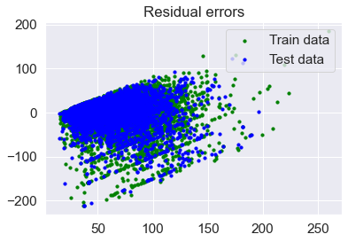

```python
plot_regression_error(linearRegression3, trainX3, trainY3, testX3, testY3)
```

#### 8.7.3 Transformation of price with percentiles for classification

The 'price' feature is binned in order to generate categorical values.

```python
dfPricesAllListingTypes3['price'].describe()
```

```
count    21881.000000
mean        56.720625
std         36.810431
min         16.000000
25%         31.000000
50%         45.000000
75%         70.000000
max        268.000000
Name: price, dtype: float64
```

```
inertia_ 29647571.181845747
inertia_ 10952425.152054831
inertia_ 5195561.180060062
inertia_ 3112965.2132134023
inertia_ 1906995.0425681705
inertia_ 1343673.020441699
inertia_ 1048576.6461750846
inertia_ 785178.0813910342
inertia_ 573827.4998944454
inertia_ 470431.5170721666
```

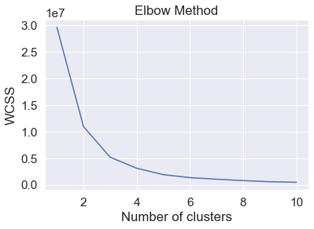

```python
kmeans_elbow_method(dfPricesAllListingTypes3['price'].values.reshape(-1,1))
```

```python
rangeClusters = enumerate([2,3,4,5])
kmeans_silhouette(dfPricesAllListingTypes3['price'].values.reshape(-1,1),
                  rangeClusters)
```

```
For n_clusters = 2 The computed average silhouette_score is : 0.6812161290185865
For n_clusters = 3 The computed average silhouette_score is : 0.6192190292916566
For n_clusters = 4 The computed average silhouette_score is : 0.58095516509882
For n_clusters = 5 The computed average silhouette_score is : 0.5897857527649103
```

The value n_clusters = 3 is chosen because it allows to have a more flexible classification.

```python
kmeansModelPrice3 = KMeans(n_clusters=3, max_iter=1000, random_state=42, n_init=50)
kmeansModelPrice3.fit(dfPricesAllListingTypes3['price'].values.reshape(-1,1))
```

```
KMeans(max_iter=1000, n_clusters=3, n_init=50, random_state=42)
```

```python
kmeansModelPrice3.cluster_centers_
```

```
array([[ 79.53538231],
       [167.35231896],
       [ 36.11264483]])
```

```python
lowClusterIndex3 = 0
mediumClusterIndex3 = 1
```

#### 8.7.4 Classification with numerical features and percentiles

```python
dfPricesNumericalListingTypes3['price_cluster'] = kmeansModelPrice3.predict(
    dfPricesNumericalListingTypes3['price'].values.reshape(-1,1))

dfPricesNumericalListingTypes3['price_cluster'] = \
    dfPricesNumericalListingTypes3['price_cluster'].apply(
        lambda x: 'low' if x==lowClusterIndex3 else
            'medium' if x==mediumClusterIndex3 else 'high')

dfPricesNumericalListingTypes3.head()
```

[output not shown]

|  | accommodates | bathrooms | bedrooms | beds | price | price_cluster |
| --- | --- | --- | --- | --- | --- | --- |
| 0 | 3 | 1.0 | 1.0 | 2.0 | 60.0 | low |
| 1 | 2 | 1.0 | 1.0 | 1.0 | 17.0 | high |
| 2 | 4 | 1.0 | 1.0 | 2.0 | 90.0 | low |
| 3 | 2 | 1.0 | 1.0 | 1.0 | 26.0 | high |
| 4 | 2 | 1.0 | 1.0 | 2.0 | 42.0 | high |

```python
trainXNumericalClass3, testXNumericalClass3, trainYNumericalClass3, testYNumericalClass3 = \
    get_train_test(dfPricesNumericalListingTypes3.iloc[:,:4],
                   dfPricesNumericalListingTypes3['price_cluster'])

trainXNumericalClass3.head()
```

|  | accommodates | bathrooms | bedrooms | beds |
| --- | --- | --- | --- | --- |
| 6514 | 3 | 1.0 | 1.0 | 1.0 |
| 14983 | 4 | 1.0 | 2.0 | 2.0 |
| 16763 | 2 | 1.0 | 1.0 | 1.0 |
| 10096 | 2 | 1.5 | 1.0 | 1.0 |
| 6876 | 2 | 1.0 | 1.0 | 1.0 |

```python
decisionTreeNumerical3 = DecisionTreeClassifier()
decisionTreeNumerical3.fit(trainXNumericalClass3, trainYNumericalClass3)
```

```
DecisionTreeClassifier()
```

```python
predictionsNumerical3 = decisionTreeNumerical3.predict(testXNumericalClass3)
```

```python
print(confusion_matrix(testYNumericalClass3, predictionsNumerical3))
print(classification_report(testYNumericalClass3, predictionsNumerical3))
```

```
[[3813  400   12]
 [1117  784   62]
 [  91  207   79]]
              precision    recall  f1-score   support

        high       0.76      0.90      0.82      4225
         low       0.56      0.40      0.47      1963
      medium       0.52      0.21      0.30       377

    accuracy                           0.71      6565
   macro avg       0.61      0.50      0.53      6565
weighted avg       0.69      0.71      0.69      6565
```

Even in this case, the classification with only the numerical features globally shows good results, with an accuracy of 71%. The results are slightly worse than the ones obtained in the previous analysis.

#### 8.7.5 Classification with all the features and percentiles

```python
dfPricesAllListingTypes3['price_cluster'] = kmeansModelPrice3.predict(
    dfPricesAllListingTypes3['price'].values.reshape(-1,1))

dfPricesAllListingTypes3['price_cluster'] = \
    dfPricesAllListingTypes3['price_cluster'].apply(
        lambda x: 'low' if x==lowClusterIndex3 else
            'medium' if x==mediumClusterIndex3 else 'high')

dfPricesAllListingTypes3.head()
```

|  | accommodates | bathrooms | bedrooms | beds | price | amenities_nr | Entire home/apt | Private room | Shared room | Airbed | Couch | Futon | Pull-out Sofa | Real Bed | price_cluster |
| --- | --- | --- | --- | --- | --- | --- | --- | --- | --- | --- | --- | --- | --- | --- | --- |
| 0 | 3 | 1.0 | 1.0 | 2.0 | 60.0 | 30 | 1 | 0 | 0 | 0 | 0 | 0 | 0 | 1 | low |
| 1 | 2 | 1.0 | 1.0 | 1.0 | 17.0 | 11 | 0 | 1 | 0 | 0 | 0 | 0 | 0 | 1 | high |
| 2 | 4 | 1.0 | 1.0 | 2.0 | 90.0 | 20 | 1 | 0 | 0 | 0 | 0 | 0 | 0 | 1 | low |
| 3 | 2 | 1.0 | 1.0 | 1.0 | 26.0 | 30 | 0 | 1 | 0 | 0 | 0 | 0 | 1 | 0 | high |
| 4 | 2 | 1.0 | 1.0 | 2.0 | 42.0 | 14 | 0 | 1 | 0 | 0 | 0 | 0 | 0 | 1 | high |

```python
trainXClass3, testXClass3, trainYClass3, testYClass3 = get_train_test(
    dfPricesAllListingTypes3.drop(columns=['price', 'price_cluster']),
    dfPricesAllListingTypes3['price_cluster'])

trainXClass3.head()
```

|  | accommodates | bathrooms | bedrooms | beds | amenities_nr | Entire home/apt | Private room | Shared room | Airbed | Couch | Futon | Pull-out Sofa | Real Bed |
| --- | --- | --- | --- | --- | --- | --- | --- | --- | --- | --- | --- | --- | --- |
| 6514 | 3 | 1.0 | 1.0 | 1.0 | 16 | 1 | 0 | 0 | 0 | 0 | 0 | 0 | 1 |
| 14983 | 4 | 1.0 | 2.0 | 2.0 | 14 | 1 | 0 | 0 | 0 | 0 | 0 | 0 | 1 |
| 16763 | 2 | 1.0 | 1.0 | 1.0 | 23 | 1 | 0 | 0 | 0 | 0 | 0 | 0 | 1 |
| 10096 | 2 | 1.5 | 1.0 | 1.0 | 16 | 0 | 1 | 0 | 0 | 0 | 0 | 0 | 1 |
| 6876 | 2 | 1.0 | 1.0 | 1.0 | 10 | 1 | 0 | 0 | 0 | 0 | 0 | 0 | 1 |

```python
decisionTree3 = DecisionTreeClassifier()
decisionTree3.fit(trainXClass3, trainYClass3)
```

```
DecisionTreeClassifier()
```

```python
predictions3 = decisionTree3.predict(testXClass3)
```

```python
print(confusion_matrix(testYClass3, predictions3))
print(classification_report(testYClass3, predictions3))
```

```
[[3612  584   29]
 [ 884  975  104]
 [  89  192   96]]
              precision    recall  f1-score   support

        high       0.79      0.85      0.82      4225
         low       0.56      0.50      0.53      1963
      medium       0.42      0.25      0.32       377

    accuracy                           0.71      6565
   macro avg       0.59      0.54      0.55      6565
weighted avg       0.70      0.71      0.70      6565
```

Even in this case, the classification with all the features globally shows good results, with an accuracy of 71%. The results are slightly worse than the ones obtained in the previous analysis.

### 8.8 Classification with balanced classes

Since all the classification reports have shown that the considered classes are strongly unbalanced, it is possible to try to perform a balancing operation. In this way, the classification model should be able to better predict the labels of the classes that were initially represented by a lower number of samples.

#### 8.8.1 Dataframe balancing

The starting dataframe is the one from which the best classification model has been built-up, that is the dataframe from which the outliers removal operation was based on the mean and the standard deviation.

```python
dfPricesListingTypesUnbalanced = dfPricesNumericalListingTypes.copy()
dfPricesListingTypesUnbalanced.head()
```

|  | accommodates | bathrooms | bedrooms | beds | price | price_cluster |
| --- | --- | --- | --- | --- | --- | --- |
| 0 | 3 | 1.0 | 1.0 | 2.0 | 60.0 | low |
| 1 | 2 | 1.0 | 1.0 | 1.0 | 17.0 | low |
| 2 | 4 | 1.0 | 1.0 | 2.0 | 90.0 | medium |
| 3 | 2 | 1.0 | 1.0 | 1.0 | 26.0 | low |
| 4 | 2 | 1.0 | 1.0 | 2.0 | 42.0 | low |

```python
dfPricesListingTypesUnbalanced.groupby('price_cluster').price.count()
```

```
price_cluster
high        532
low       16336
medium     5553
Name: price, dtype: int64
```

In order to balance the classes, the data-points with label 'high' need to be over-sampled, while the data-points with label 'low' need to be under-sampled. The desired number of data-points for each label of 'price_cluster' is the number of data-points with the label 'medium'.

```python
from sklearn.utils import resample

def over_sample(df, label, length):
    df_label = df[df['price_cluster'] == label]
    df_label_oversampled = resample(df_label, replace=True,
                                    n_samples=length, random_state=42)

    return df_label_oversampled

def under_sample(df, label, length):
    df_label = df[df['price_cluster'] == label]
    df_label_undersampled = df_label.sample(n=length)

    return df_label_undersampled
```

```python
def create_balanced_df(df):
    df_medium_price_cluster_balanced = df[df['price_cluster'] == 'medium']

    df_low_price_cluster_balanced = \
        under_sample(df, 'low', df_medium_price_cluster_balanced.shape[0])

    df_high_price_cluster_balanced = \
        over_sample(df, 'high', df_medium_price_cluster_balanced.shape[0])

    return pd.concat([df_low_price_cluster_balanced,
                      df_medium_price_cluster_balanced,
                      df_high_price_cluster_balanced])
```

```python
dfPricesListingTypesBalanced = create_balanced_df(dfPricesListingTypesUnbalanced)
dfPricesListingTypesBalanced.head()
```

|  | accommodates | bathrooms | bedrooms | beds | price | price_cluster |
| --- | --- | --- | --- | --- | --- | --- |
| 2476 | 2 | 1.0 | 1.0 | 2.0 | 25.0 | low |
| 13762 | 1 | 1.5 | 1.0 | 1.0 | 40.0 | low |
| 21118 | 2 | 1.0 | 1.0 | 1.0 | 47.0 | low |
| 1690 | 2 | 1.0 | 0.0 | 1.0 | 45.0 | low |
| 16696 | 2 | 1.0 | 1.0 | 1.0 | 58.0 | low |

```python
dfPricesListingTypesBalanced.groupby('price_cluster').price.count()
```

```
price_cluster
high      5553
low       5553
medium    5553
Name: price, dtype: int64
```

#### 8.8.2 Classification with balanced dataframe

Once the balanced dataframe is available, it is possible to perform a new classification experiment.

The performed steps are always the same.

```python
trainXBalancedClass, testXBalancedClass, trainYBalancedClass, testYBalancedClass = \
    get_train_test(dfPricesListingTypesBalanced.iloc[:,:4],
                   dfPricesListingTypesBalanced['price_cluster'])

trainXBalancedClass.head()
```

|  | accommodates | bathrooms | bedrooms | beds |
| --- | --- | --- | --- | --- |
| 10216 | 2 | 2.0 | 1.0 | 1.0 |
| 3653 | 2 | 1.0 | 1.0 | 1.0 |
| 8212 | 5 | 1.0 | 2.0 | 2.0 |
| 18101 | 2 | 1.0 | 1.0 | 1.0 |
| 16740 | 4 | 1.0 | 1.0 | 2.0 |

```python
decisionTreeBalanced = DecisionTreeClassifier()
decisionTreeBalanced.fit(trainXBalancedClass, trainYBalancedClass)
```

```
DecisionTreeClassifier()
```

```python
predictionsBalanced = decisionTreeBalanced.predict(testXBalancedClass)
```

```python
print(confusion_matrix(testYBalancedClass, predictionsBalanced))
print(classification_report(testYBalancedClass, predictionsBalanced))
```

```
[[1173  187  256]
 [  45 1324  316]
 [ 259  627  811]]
              precision    recall  f1-score   support

        high       0.79      0.73      0.76      1616
         low       0.62      0.79      0.69      1685
      medium       0.59      0.48      0.53      1697

    accuracy                           0.66      4998
   macro avg       0.67      0.66      0.66      4998
weighted avg       0.66      0.66      0.66      4998
```

With the balanced classes, the model shows precision and recall values that are better with respect to the other classification models. However, the global accuracy of the model is around 10% lower with respect to the other ones.

## 9. Conclusions

The final considerations about the performed analysis can be reported.

### 9.1 Sentiment analysis

Concerning the sentiment analysis, the obtained results show that it is possible to reach an accuracy value that is very close to the one obtained by an already-existing external library. In particular, these results have been reached through the use of many pre-processing techniques, such as the tokenization of the reviews, the normalization of the words and removal of the stop words. Furthermore, the use of the Word2Vec technique, combined with both the clustering for the detection of the sentiment of each word, and the TF-IDF technique for the weight of the words inside each review, has shown very good results.

### 9.2 Correlation analysis

Concerning the correlation analysis performed over the feature 'price', the obtained results are not very satisfactory.

In particular, concerning the correlation between the 'price' and the calendar features, the correlation matrices have always shown a very high correlation between the average price of the listings and the different values of the calendar features. In only one case, indeed, it is possible to notice a correlation value that is lower than 0.9. This case concerns the correlation of the average price during the 'winter' and the 'summer' seasons, and they show a correlation value of 0.89.

So, it is not possible to identify some correlation relationships between the 'price' of a room and the considered calendar features.

So, it is not possible to predict with a good confidence the price of a room given its characteristics.